# Section: Importing modules

```python
import pandas as pd
import numpy as np
import matplotlib
import matplotlib.pyplot as plt
from IPython.display import display
import IPython.core.display as di
from include.config import CleaningConfig, PlottingConfig, NotebookConfig
from include.counting import get_count, get_percentage
from include.plotting import get_plot, display_side_by_side
from include.likertScalePlot import likert_scale
from include.textCleaning import wordcloud
```

```python
pd.set_option('display.max_rows', 1000)
pd.set_option('display.max_columns', 1000)
```

This text is used to hide the code cell when exported in html

```python
di.display_html('<script>jQuery(function() {if (jQuery("body.notebook_app").length == 0) { jQuery(".input_area").toggle(); jQuery(".prompt").toggle();}});</script>', raw=True)
```

```python
get_ipython().magic('matplotlib inline')  # Activate that line to use in Jupyter
matplotlib.rcParams['figure.figsize'] = (15.0, 8.0)
```

# Loading dataset

```python
df =  pd.read_csv('./uk_2017/data/cleaned_data.csv')
```

The total of participant after cleaning the dataset. Remove all participants that have not completed the survey passed the first pages and all participants who are not from the country

```python
len(df)
```

```
253
```

# Section: 1

## Group of question: socio

### In which country do you work?

```python
v_to_count, filename  = get_count(df, ['socio1. In which country do you work?'], "one choice", "./../survey_creation/uk_17/listAnswers/countries.csv", "False", "./uk_2017/output/")
```

```python
perc_to_count = get_percentage(v_to_count, filename)
```

```python
display_side_by_side(v_to_count,perc_to_count)
```

|  | In which country do you work? |
| --- | --- |
| United Kingdom | 253 |

|  | In which country do you work? [PERCENTAGE] |
| --- | --- |
| United Kingdom [PERCENTAGE] | 100.0 |

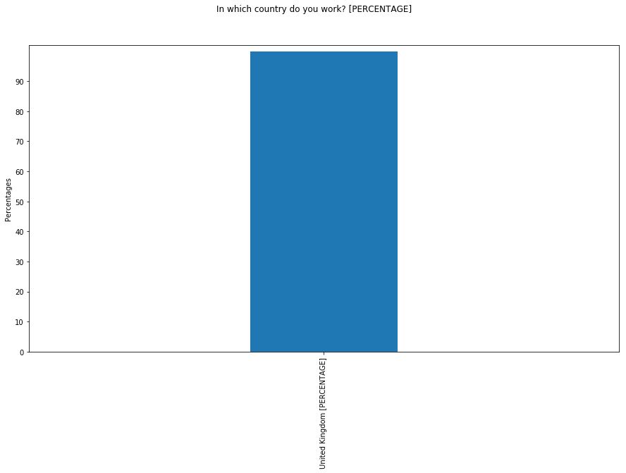

```python
_ = get_plot(perc_to_count, "one choice")
```

## Group of question: edu

### What is the highest qualification you have obtained?

```python
v_to_count, filename  = get_count(df, ['edu1. What is the highest qualification you have obtained?'], "one choice", "./../survey_creation/uk_17/listAnswers/education.csv", "True", "./uk_2017/output/")
```

```python
perc_to_count = get_percentage(v_to_count, filename)
```

```python
display_side_by_side(v_to_count,perc_to_count)
```

|  | What is the highest qualification you have obtained? |
| --- | --- |
| Undergraduate degree | 170 |
| Master degree | 56 |
| Doctorate | 25 |
| Other | 2 |

|  | What is the highest qualification you have obtained? [PERCENTAGE] |
| --- | --- |
| Undergraduate degree | 67.19 |
| Master degree | 22.13 |
| Doctorate | 9.88 |
| Other | 0.79 |

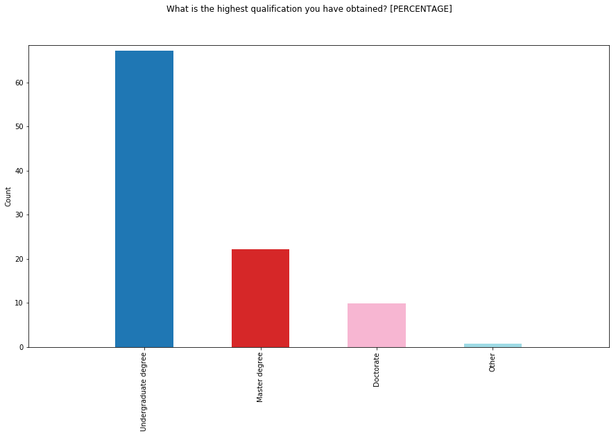

```python
_ = get_plot(perc_to_count, "one choice")
```

### In which subject is your highest academic qualification?

```python
v_to_count, filename  = get_count(df, ['edu2. In which subject is your highest academic qualification?'], "one choice", "./../survey_creation/uk_17/listAnswers/academic_field.csv", "False", "./uk_2017/output/")
```

```python
perc_to_count = get_percentage(v_to_count, filename)
```

```python
display_side_by_side(v_to_count,perc_to_count)
```

|  | In which subject is your highest academic qualification? |
| --- | --- |
| Computer Science | 69 |
| Physics and Astronomy | 69 |
| Mathematics | 19 |
| Chemistry | 16 |
| Biological Sciences | 15 |
| Other | 12 |
| Geography & Environmental Sciences | 10 |
| Electrical & Electronic Engineering | 8 |
| Civil Engineering | 6 |
| Mechanical Engineering | 4 |
| Geology | 3 |
| Linguistics | 3 |
| Materials Technology | 3 |
| Psychology | 3 |
| General Engineering | 3 |
| Medicine | 2 |
| Aeronautical & Manufacturing Engineering | 2 |
| History | 1 |
| Theology & Religious Studies | 1 |
| Art & Design | 1 |
| Robotics | 1 |
| NaN | 2 |

|  | In which subject is your highest academic qualification? [PERCENTAGE] |
| --- | --- |
| Computer Science | 27.49 |
| Physics and Astronomy | 27.49 |
| Mathematics | 7.57 |
| Chemistry | 6.37 |
| Biological Sciences | 5.98 |
| Other | 4.78 |
| Geography & Environmental Sciences | 3.98 |
| Electrical & Electronic Engineering | 3.19 |
| Civil Engineering | 2.39 |
| Mechanical Engineering | 1.59 |
| Geology | 1.20 |
| Linguistics | 1.20 |
| Materials Technology | 1.20 |
| Psychology | 1.20 |
| General Engineering | 1.20 |
| Medicine | 0.80 |
| Aeronautical & Manufacturing Engineering | 0.80 |
| History | 0.40 |
| Theology & Religious Studies | 0.40 |
| Art & Design | 0.40 |
| Robotics | 0.40 |

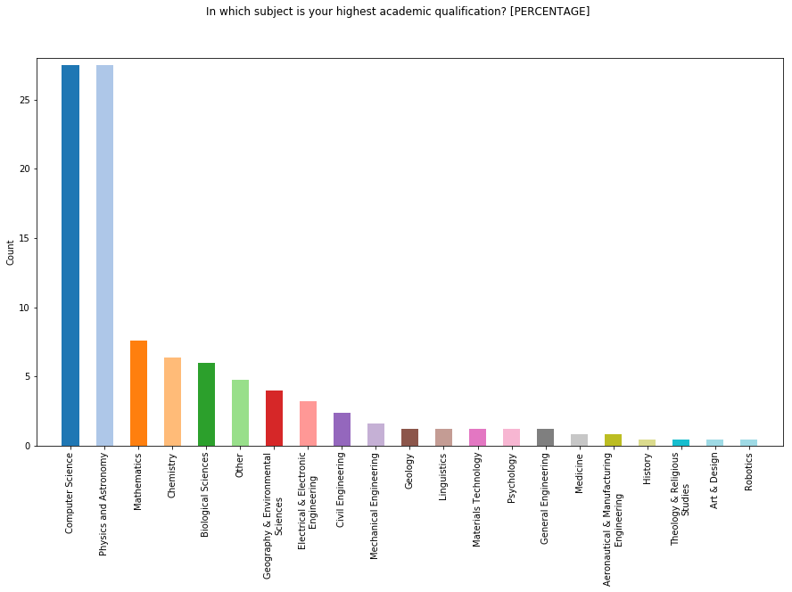

```python
_ = get_plot(perc_to_count, "one choice")
```

### Enter your academic subject

### Do you hold any other professional qualifications?

## Group of question: rse

### Do you write code as part of your job?

```python
v_to_count, filename  = get_count(df, ['rse1. Do you write code as part of your job?'], "y/n/na", "./../survey_creation/uk_17/listAnswers/.csv", "False", "./uk_2017/output/")
```

```python
perc_to_count = get_percentage(v_to_count, filename)
```

```python
display_side_by_side(v_to_count,perc_to_count)
```

|  | Yes | No |
| --- | --- | --- |
| Do you write code as part of your job? | 246 | 7 |

|  | Yes | No |
| --- | --- | --- |
| Do you write code as part of your job? [PERCENTAGE] | 97.23 | 2.77 |

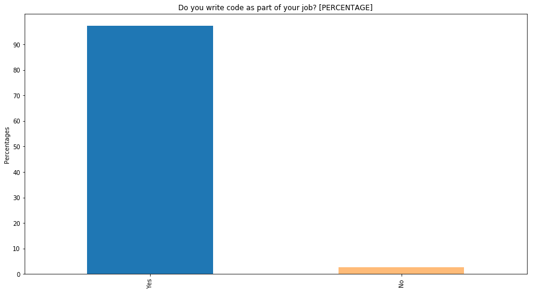

```python
_ = get_plot(perc_to_count, "y/n/na")
```

### Who uses the code that you write?

```python
v_to_count, filename  = get_count(df, ['rse3[SQ001]. Who uses the code that you write? []'], "likert", "./../survey_creation/uk_17/listAnswers/likert_usage_5.csv", "False", "./uk_2017/output/")
```

```python
display(v_to_count)
```

|  | 0 - Mostly me | 1 | 2 | 3 | 4 | 5 - Mostly other people |
| --- | --- | --- | --- | --- | --- | --- |
| Who uses the code that you write? [] | 7 | 34 | 31 | 38 | 60 | 76 |

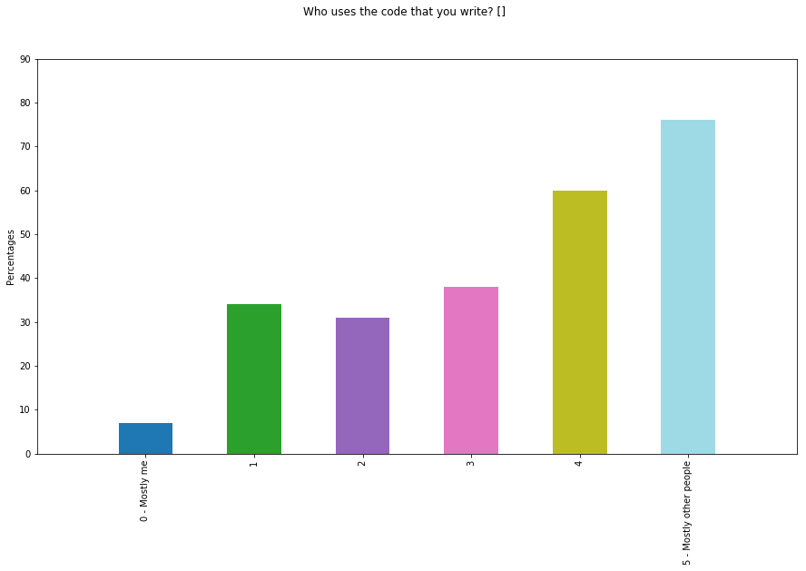

```python
_ = get_plot(v_to_count, "likert")
```

## Group of question: soft

### Do you consider yourself a professional software developer?

```python
v_to_count, filename  = get_count(df, ['soft2can. Do you consider yourself a professional software developer?'], "y/n/na", "./../survey_creation/uk_17/listAnswers/.csv", "False", "./uk_2017/output/")
```

```python
perc_to_count = get_percentage(v_to_count, filename)
```

```python
display_side_by_side(v_to_count,perc_to_count)
```

|  | Yes | No |
| --- | --- | --- |
| Do you consider yourself a professional software developer? | 147 | 106 |

|  | Yes | No |
| --- | --- | --- |
| Do you consider yourself a professional software developer? [PERCENTAGE] | 58.1 | 41.9 |

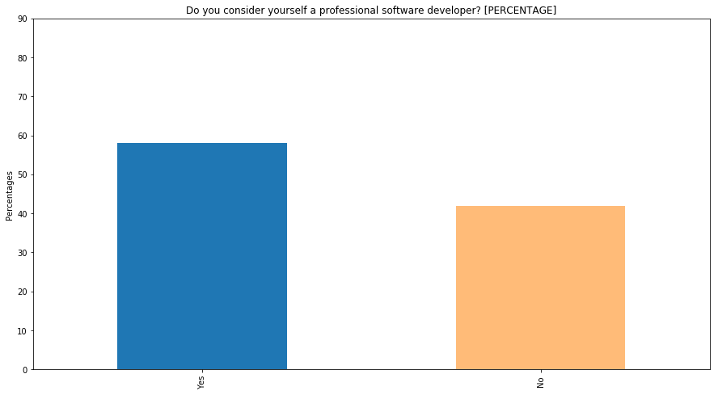

```python
_ = get_plot(perc_to_count, "y/n/na")
```

### How many years of Software development experience do you have?

```python
v_to_count, filename  = get_count(df, ['soft1can. How many years of software development experience do you have?'], "freenumeric", "./../survey_creation/uk_17/listAnswers/.csv", "False", "./uk_2017/output/")
```

```python
perc_to_count = get_percentage(v_to_count, filename)
```

```python
display_side_by_side(v_to_count,perc_to_count)
```

|  | How many years of software development experience do you have? |
| --- | --- |
| 0 | 15.0 |
| 1 | 9.0 |
| 2 | NaN |
| 3 | 20.0 |
| 4 | 14.0 |
| 5 | 25.0 |
| 6 | NaN |
| 7 | 18.0 |
| 8 | NaN |
| 9 | NaN |
| 10 | 12.0 |
| 11 | 16.0 |
| 12 | 7.0 |
| 13 | 5.0 |
| 14 | 20.0 |
| 15 | 15.0 |
| 16 | 9.0 |
| 17 | 30.0 |
| 18 | 15.0 |
| 19 | NaN |
| 20 | 30.0 |
| 21 | 15.0 |
| 22 | 13.0 |
| 23 | 7.0 |
| 24 | 10.0 |
| 25 | 5.0 |
| 26 | 5.0 |
| 27 | 10.0 |
| 28 | NaN |
| 29 | 19.0 |

[output cut: 223 more lines]

[output not shown]

[output cut: 223 more lines]

```
       How many years of software development experience do you have?
count                                         147.000000
mean                                           13.707483
std                                             7.823578
min                                             1.000000
25%                                             8.000000
50%                                            12.000000
75%                                            18.500000
max                                            40.000000
```

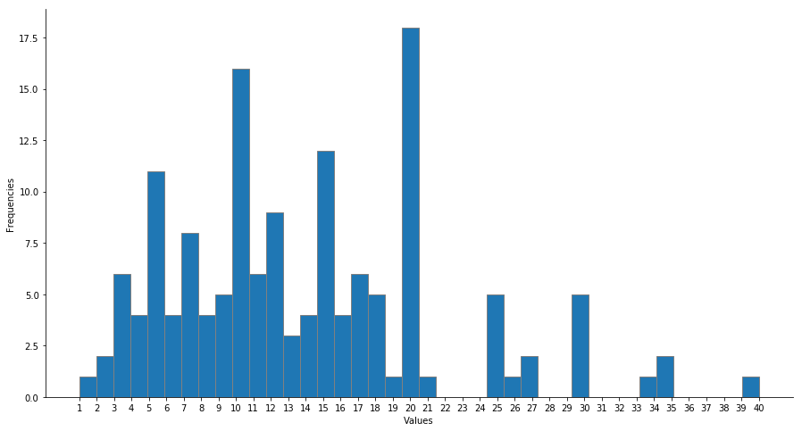

```python
_ = get_plot(v_to_count, "freenumeric")
```

## Group of question: time

### In an average month, how much time do you spend on software development (Please rate your answer between 1 to 10. 1 Being none at all and 10 being All your time.)

```python
v_to_count, filename  = get_count(df, ['time1can[time1can]. In an average month, how much time do you spend on: [Software development]', 'time1can[time2can]. In an average month, how much time do you spend on: [Research]', 'time1can[time3can]. In an average month, how much time do you spend on: [People management]', 'time1can[time6can]. In an average month, how much time do you spend on: [Project management]', 'time1can[time4can]. In an average month, how much time do you spend on: [Teaching]', 'time1can[time5can]. In an average month, how much time do you spend on: [Other activities]'], "likert", "./../survey_creation/uk_17/listAnswers/likert_time_10.csv", "False", "./uk_2017/output/")
```

```python
display(v_to_count)
```

|  | 1 (None at all) | 2 | 3 | 4 | 5 | 6 | 7 | 8 | 9 | 10 (All my time) |
| --- | --- | --- | --- | --- | --- | --- | --- | --- | --- | --- |
| Software development | 5.0 | 16.0 | 24.0 | 35.0 | 35.0 | 24.0 | 50.0 | 41.0 | 16.0 | 7.0 |
| Research | 45.0 | 58.0 | 37.0 | 29.0 | 25.0 | 20.0 | 20.0 | 10.0 | 7.0 | 2.0 |
| People management | 102.0 | 76.0 | 33.0 | 16.0 | 6.0 | 7.0 | 7.0 | 5.0 | NaN | 1.0 |
| Project management | 32.0 | 86.0 | 58.0 | 23.0 | 26.0 | 11.0 | 9.0 | 4.0 | 2.0 | 2.0 |
| Teaching | 109.0 | 77.0 | 33.0 | 17.0 | 6.0 | 8.0 | 1.0 | NaN | 1.0 | 1.0 |
| Other activities | 52.0 | 88.0 | 40.0 | 29.0 | 19.0 | 10.0 | 10.0 | NaN | 3.0 | 2.0 |

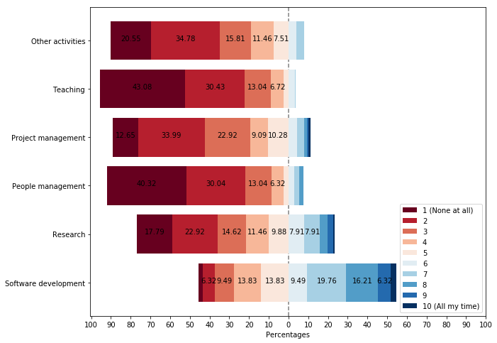

```python
_ = get_plot(v_to_count, "likert")
```

# Section: 2

## Group of question: currentEmp

### What type of organisation do you work for?

```python
v_to_count, filename  = get_count(df, ['currentEmp1. What type of organisation do you work for?'], "one choice", "./../survey_creation/uk_17/listAnswers/type_organisation.csv", "False", "./uk_2017/output/")
```

```python
perc_to_count = get_percentage(v_to_count, filename)
```

```python
display_side_by_side(v_to_count,perc_to_count)
```

|  | What type of organisation do you work for? |
| --- | --- |
| University - within an academic group | 128 |
| National laboratory | 41 |
| University - within an IT service | 21 |
| University - within an HPC group | 18 |
| Government | 17 |
| Other | 13 |
| Private company | 8 |
| NGO | 7 |

|  | What type of organisation do you work for? [PERCENTAGE] |
| --- | --- |
| University - within an academic group | 50.59 |
| National laboratory | 16.21 |
| University - within an IT service | 8.30 |
| University - within an HPC group | 7.11 |
| Government | 6.72 |
| Other | 5.14 |
| Private company | 3.16 |
| NGO | 2.77 |

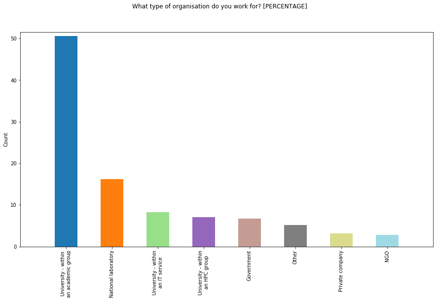

```python
_ = get_plot(perc_to_count, "one choice")
```

### Which University?

```python
v_to_count, filename  = get_count(df, ['currentEmp2. Which university?'], "one choice", "./../survey_creation/uk_17/listAnswers/universities.csv", "False", "./uk_2017/output/")
```

```python
perc_to_count = get_percentage(v_to_count, filename)
```

```python
display_side_by_side(v_to_count,perc_to_count)
```

|  | Which university? |
| --- | --- |
| University of Edinburgh | 23 |
| University of Sheffield | 14 |
| University of Oxford | 11 |
| University College London (UCL) | 11 |
| University of Manchester | 11 |
| University of St Andrews | 10 |
| University of Cambridge | 9 |
| University of Southampton | 8 |
| University of Leeds | 7 |
| University of Bristol | 7 |
| Imperial College London | 6 |
| University of Birmingham | 5 |
| University of Warwick, Coventry | 4 |
| University of Dundee | 3 |
| University of Reading | 3 |
| University of Bath | 3 |
| Newcastle University | 3 |
| Other | 2 |
| Bournemouth University | 2 |
| University of Exeter | 2 |
| King's College London | 2 |
| Durham University, Durham and Stockton-on-Tees (Queen's Campus) | 2 |
| University of Glasgow | 2 |
| University of York | 2 |
| Heriot-Watt University, Edinburgh and Galashiels | 1 |
| St George's, University of London | 1 |
| University of Sussex, Falmer and Brighton | 1 |
| Bangor University | 1 |
| Queen Mary, University of London | 1 |
| Birkbeck, University of London | 1 |
| University of Gloucestershire, Cheltenham, Gloucester and London | 1 |
| University of Leicester | 1 |
| Royal Veterinary College | 1 |
| Cranfield University, Cranfield, and Shrivenham | 1 |
| University of Liverpool | 1 |
| University of Nottingham | 1 |
| Swansea University | 1 |
| NaN | 88 |

|  | Which university? [PERCENTAGE] |
| --- | --- |
| University of Edinburgh | 13.94 |
| University of Sheffield | 8.48 |
| University of Oxford | 6.67 |
| University College London (UCL) | 6.67 |
| University of Manchester | 6.67 |
| University of St Andrews | 6.06 |
| University of Cambridge | 5.45 |
| University of Southampton | 4.85 |
| University of Leeds | 4.24 |
| University of Bristol | 4.24 |
| Imperial College London | 3.64 |
| University of Birmingham | 3.03 |
| University of Warwick, Coventry | 2.42 |
| University of Dundee | 1.82 |
| University of Reading | 1.82 |
| University of Bath | 1.82 |
| Newcastle University | 1.82 |
| Other | 1.21 |
| Bournemouth University | 1.21 |
| University of Exeter | 1.21 |
| King's College London | 1.21 |
| Durham University, Durham and Stockton-on-Tees (Queen's Campus) | 1.21 |
| University of Glasgow | 1.21 |
| University of York | 1.21 |
| Heriot-Watt University, Edinburgh and Galashiels | 0.61 |
| St George's, University of London | 0.61 |
| University of Sussex, Falmer and Brighton | 0.61 |
| Bangor University | 0.61 |
| Queen Mary, University of London | 0.61 |
| Birkbeck, University of London | 0.61 |
| University of Gloucestershire, Cheltenham, Gloucester and London | 0.61 |
| University of Leicester | 0.61 |
| Royal Veterinary College | 0.61 |
| Cranfield University, Cranfield, and Shrivenham | 0.61 |
| University of Liverpool | 0.61 |
| University of Nottingham | 0.61 |
| Swansea University | 0.61 |

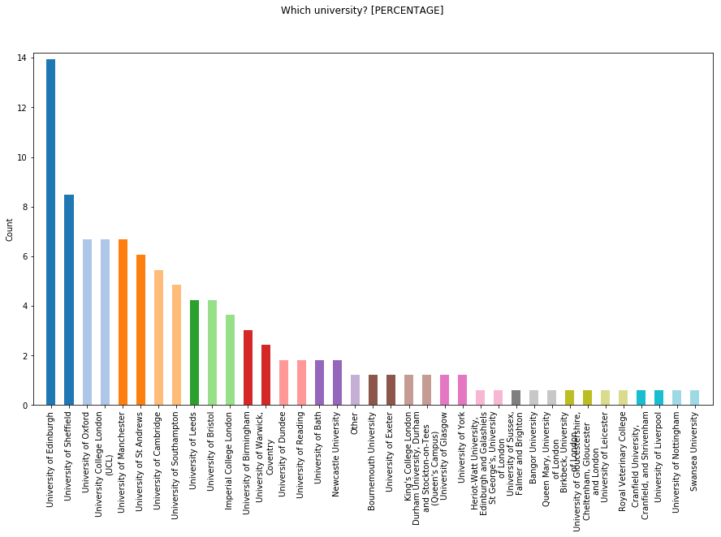

```python
_ = get_plot(perc_to_count, "one choice")
```

### Which organisation do you work for?

### What is your official job title?

### Are you known by a different job title? If so, please enter the job title you use

### Do you work full time or part time

```python
v_to_count, filename  = get_count(df, ['currentEmp12. Do you work full time or part time?'], "one choice", "./../survey_creation/uk_17/listAnswers/type_hours.csv", "False", "./uk_2017/output/")
```

```python
perc_to_count = get_percentage(v_to_count, filename)
```

```python
display_side_by_side(v_to_count,perc_to_count)
```

|  | Do you work full time or part time? |
| --- | --- |
| Full Time | 242 |
| Part-time | 11 |

|  | Do you work full time or part time? [PERCENTAGE] |
| --- | --- |
| Full Time | 95.65 |
| Part-time | 4.35 |

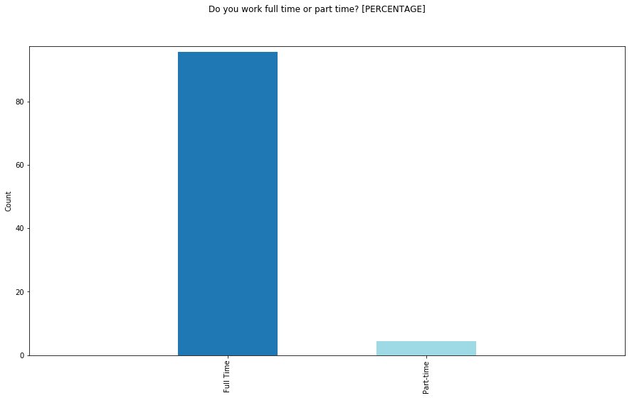

```python
_ = get_plot(perc_to_count, "one choice")
```

### What type of contract are you employed on?

```python
v_to_count, filename  = get_count(df, ['currentEmp10. What type of contract are you employed on?'], "one choice", "./../survey_creation/uk_17/listAnswers/type_contract.csv", "False", "./uk_2017/output/")
```

```python
perc_to_count = get_percentage(v_to_count, filename)
```

```python
display_side_by_side(v_to_count,perc_to_count)
```

|  | What type of contract are you employed on? |
| --- | --- |
| Fixed term | 92 |
| Permanent -- funded by University core funding | 77 |
| Permanent -- as long as funding is available | 65 |
| Other/Not listed | 15 |
| Agency staff | 3 |
| Freelancer consultant contractor | 1 |

|  | What type of contract are you employed on? [PERCENTAGE] |
| --- | --- |
| Fixed term | 36.36 |
| Permanent -- funded by University core funding | 30.43 |
| Permanent -- as long as funding is available | 25.69 |
| Other/Not listed | 5.93 |
| Agency staff | 1.19 |
| Freelancer consultant contractor | 0.40 |

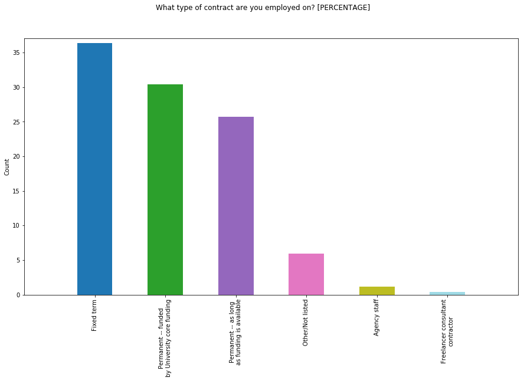

```python
_ = get_plot(perc_to_count, "one choice")
```

### When did you start your current contract

### What is the duration of your current contract?

```python
v_to_count, filename  = get_count(df, ['currentEmp11. What is the duration of your current contract in months?'], "freenumeric", "./../survey_creation/uk_17/listAnswers/.csv", "False", "./uk_2017/output/")
```

```python
perc_to_count = get_percentage(v_to_count, filename)
```

```python
display_side_by_side(v_to_count,perc_to_count)
```

|  | What is the duration of your current contract in months? |
| --- | --- |
| 0 | NaN |
| 1 | 60.0 |
| 2 | 48.0 |
| 3 | NaN |
| 4 | NaN |
| 5 | NaN |
| 6 | 18.0 |
| 7 | NaN |
| 8 | 24.0 |
| 9 | NaN |
| 10 | 36.0 |
| 11 | NaN |
| 12 | NaN |
| 13 | NaN |
| 14 | 48.0 |
| 15 | NaN |
| 16 | NaN |
| 17 | 60.0 |
| 18 | 60.0 |
| 19 | NaN |
| 20 | NaN |
| 21 | NaN |
| 22 | NaN |
| 23 | NaN |
| 24 | NaN |
| 25 | 36.0 |
| 26 | 29.0 |
| 27 | 30.0 |
| 28 | 36.0 |
| 29 | NaN |

[output cut: 223 more lines]

[output not shown]

[output cut: 223 more lines]

```
       What is the duration of your current contract in months?
count                                          92.000000
mean                                           31.385870
std                                            15.376431
min                                             1.500000
25%                                            20.250000
50%                                            36.000000
75%                                            36.000000
max                                            72.000000
```

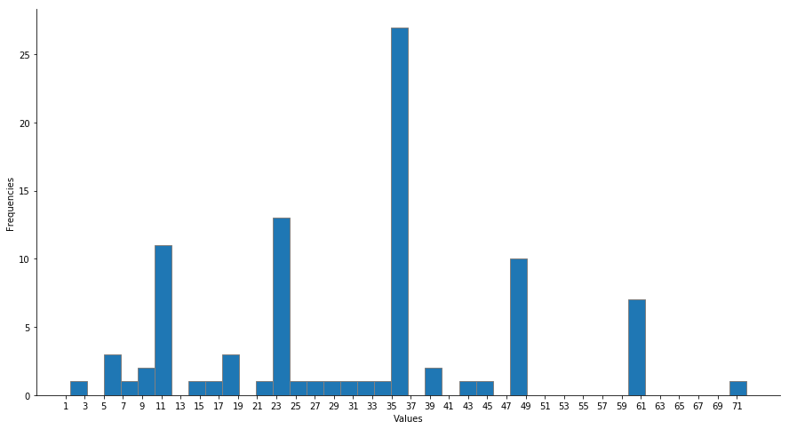

```python
_ = get_plot(v_to_count, "freenumeric")
```

### In which disciplines do you work (select as many as apply)

```python
v_to_count, filename  = get_count(df, ['currentEmp13[SQ001]. In which disciplines do you work (select as many as apply)? [Accounting & Finance]', 'currentEmp13[SQ002]. In which disciplines do you work (select as many as apply)? [Aeronautical & Manufacturing Engineering]', 'currentEmp13[SQ003]. In which disciplines do you work (select as many as apply)? [Agriculture & Forestry]', 'currentEmp13[SQ004]. In which disciplines do you work (select as many as apply)? [American Studies]', 'currentEmp13[SQ005]. In which disciplines do you work (select as many as apply)? [Anatomy & Physiology]', 'currentEmp13[SQ006]. In which disciplines do you work (select as many as apply)? [Anthropology]', 'currentEmp13[SQ007]. In which disciplines do you work (select as many as apply)? [Architecture]', 'currentEmp13[SQ008]. In which disciplines do you work (select as many as apply)? [Art & Design]', 'currentEmp13[SQ009]. In which disciplines do you work (select as many as apply)? [Biological Sciences]', 'currentEmp13[SQ010]. In which disciplines do you work (select as many as apply)? [Business & Management Studies]', 'currentEmp13[SQ011]. In which disciplines do you work (select as many as apply)? [Chemical Engineering]', 'currentEmp13[SQ012]. In which disciplines do you work (select as many as apply)? [Chemistry]', 'currentEmp13[SQ013]. In which disciplines do you work (select as many as apply)? [Civil Engineering]', 'currentEmp13[SQ014]. In which disciplines do you work (select as many as apply)? [Classics & Ancient History]', 'currentEmp13[SQ015]. In which disciplines do you work (select as many as apply)? [Communication & Media Studies]', 'currentEmp13[SQ016]. In which disciplines do you work (select as many as apply)? [Complementary Medicine]', 'currentEmp13[SQ017]. In which disciplines do you work (select as many as apply)? [Computer Science]', 'currentEmp13[SQ018]. In which disciplines do you work (select as many as apply)? [Counselling]', 'currentEmp13[SQ019]. In which disciplines do you work (select as many as apply)? [Criminology]', 'currentEmp13[SQ020]. In which disciplines do you work (select as many as apply)? [Dentistry]', 'currentEmp13[SQ021]. In which disciplines do you work (select as many as apply)? [East & South Asian Studies]', 'currentEmp13[SQ022]. In which disciplines do you work (select as many as apply)? [Economics]', 'currentEmp13[SQ023]. In which disciplines do you work (select as many as apply)? [Education]', 'currentEmp13[SQ024]. In which disciplines do you work (select as many as apply)? [Electrical & Electronic Engineering]', 'currentEmp13[SQ025]. In which disciplines do you work (select as many as apply)? [English]', 'currentEmp13[SQ026]. In which disciplines do you work (select as many as apply)? [Fashion]', 'currentEmp13[SQ027]. In which disciplines do you work (select as many as apply)? [Food Science]', 'currentEmp13[SQ028]. In which disciplines do you work (select as many as apply)? [French]', 'currentEmp13[SQ029]. In which disciplines do you work (select as many as apply)? [Geography & Environmental Sciences]', 'currentEmp13[SQ030]. In which disciplines do you work (select as many as apply)? [Geology]', 'currentEmp13[SQ031]. In which disciplines do you work (select as many as apply)? [General Engineering]', 'currentEmp13[SQ032]. In which disciplines do you work (select as many as apply)? [German]', 'currentEmp13[SQ033]. In which disciplines do you work (select as many as apply)? [History]', 'currentEmp13[SQ034]. In which disciplines do you work (select as many as apply)? [History of Art, Architecture & Design]', 'currentEmp13[SQ035]. In which disciplines do you work (select as many as apply)? [Hospitality, Leisure, Recreation & Tourism]', 'currentEmp13[SQ036]. In which disciplines do you work (select as many as apply)? [Iberian Languages/Hispanic Studies]', 'currentEmp13[SQ037]. In which disciplines do you work (select as many as apply)? [Land & Property Management]', 'currentEmp13[SQ038]. In which disciplines do you work (select as many as apply)? [Law]', 'currentEmp13[SQ039]. In which disciplines do you work (select as many as apply)? [Librarianship & Information Management]', 'currentEmp13[SQ040]. In which disciplines do you work (select as many as apply)? [Linguistics]', 'currentEmp13[SQ041]. In which disciplines do you work (select as many as apply)? [Marketing]', 'currentEmp13[SQ042]. In which disciplines do you work (select as many as apply)? [Materials Technology]', 'currentEmp13[SQ043]. In which disciplines do you work (select as many as apply)? [Mathematics]', 'currentEmp13[SQ044]. In which disciplines do you work (select as many as apply)? [Mechanical Engineering]', 'currentEmp13[SQ045]. In which disciplines do you work (select as many as apply)? [Medicine]', 'currentEmp13[SQ046]. In which disciplines do you work (select as many as apply)? [Middle Eastern and African Studies]', 'currentEmp13[SQ047]. In which disciplines do you work (select as many as apply)? [Music]', 'currentEmp13[SQ048]. In which disciplines do you work (select as many as apply)? [Nursing]', 'currentEmp13[SQ049]. In which disciplines do you work (select as many as apply)? [Ophthalmics]', 'currentEmp13[SQ050]. In which disciplines do you work (select as many as apply)? [Pharmacology & Pharmacy]', 'currentEmp13[SQ051]. In which disciplines do you work (select as many as apply)? [Philosophy]', 'currentEmp13[SQ052]. In which disciplines do you work (select as many as apply)? [Physics and Astronomy]', 'currentEmp13[SQ053]. In which disciplines do you work (select as many as apply)? [Physiotherapy]', 'currentEmp13[SQ054]. In which disciplines do you work (select as many as apply)? [Politics]', 'currentEmp13[SQ055]. In which disciplines do you work (select as many as apply)? [Psychology]', 'currentEmp13[SQ056]. In which disciplines do you work (select as many as apply)? [Robotics]', 'currentEmp13[SQ057]. In which disciplines do you work (select as many as apply)? [Russian & East European Languages]', 'currentEmp13[SQ058]. In which disciplines do you work (select as many as apply)? [Social Policy]', 'currentEmp13[SQ059]. In which disciplines do you work (select as many as apply)? [Social Work]', 'currentEmp13[SQ060]. In which disciplines do you work (select as many as apply)? [Sociology]', 'currentEmp13[SQ061]. In which disciplines do you work (select as many as apply)? [Sports Science]', 'currentEmp13[SQ062]. In which disciplines do you work (select as many as apply)? [Theology & Religious Studies]', 'currentEmp13[SQ063]. In which disciplines do you work (select as many as apply)? [Town & Country Planning and Landscape Design]', 'currentEmp13[SQ064]. In which disciplines do you work (select as many as apply)? [Veterinary Medicine]', 'currentEmp13[SQ065]. In which disciplines do you work (select as many as apply)? [Youth Work]'], "multiple choices", "./../survey_creation/uk_17/listAnswers/academic_field.csv", "False", "./uk_2017/output/")
```

```python
perc_to_count = get_percentage(v_to_count, filename)
```

```python
display_side_by_side(v_to_count,perc_to_count)
```

|  | Count |
| --- | --- |
| Computer Science | 112 |
| Biological Sciences | 87 |
| Physics and Astronomy | 80 |
| Mathematics | 42 |
| Chemistry | 39 |
| Medicine | 37 |
| Geography & Environmental Sciences | 34 |
| Electrical & Electronic Engineering | 25 |
| Mechanical Engineering | 24 |
| General Engineering | 20 |
| Materials Technology | 17 |
| Education | 15 |
| Psychology | 12 |
| Chemical Engineering | 12 |
| Civil Engineering | 12 |
| Aeronautical & Manufacturing Engineering | 11 |
| Geology | 11 |
| Linguistics | 11 |
| Anatomy & Physiology | 11 |
| Librarianship & Information Management | 9 |
| Robotics | 9 |
| History | 8 |
| Architecture | 8 |
| Sociology | 8 |
| Economics | 8 |
| Classics & Ancient History | 7 |
| Social Policy | 7 |
| Business & Management Studies | 7 |
| Pharmacology & Pharmacy | 6 |
| Agriculture & Forestry | 6 |
| Middle Eastern and African Studies | 5 |
| Anthropology | 5 |
| Ophthalmics | 4 |
| Food Science | 4 |
| Theology & Religious Studies | 4 |
| Town & Country Planning and Landscape Design | 4 |
| Communication & Media Studies | 4 |
| Art & Design | 4 |
| History of Art, Architecture & Design | 3 |
| Law | 3 |
| Nursing | 3 |
| Politics | 2 |
| Land & Property Management | 2 |
| Philosophy | 2 |
| English | 2 |
| Physiotherapy | 1 |
| Social Work | 1 |
| Sports Science | 1 |
| Veterinary Medicine | 1 |
| Youth Work | 1 |
| Music | 1 |
| Marketing | 1 |
| Iberian Languages/Hispanic Studies | 1 |
| Hospitality, Leisure, Recreation & Tourism | 1 |
| German | 1 |
| French | 1 |
| Fashion | 1 |
| East & South Asian Studies | 1 |
| Dentistry | 1 |
| Criminology | 1 |
| Counselling | 1 |
| Complementary Medicine | 1 |
| American Studies | 1 |
| Russian & East European Languages | 0 |
| Accounting & Finance | 0 |

|  | Count [PERCENTAGE] |
| --- | --- |
| Computer Science | 14.66 |
| Biological Sciences | 11.39 |
| Physics and Astronomy | 10.47 |
| Mathematics | 5.50 |
| Chemistry | 5.10 |
| Medicine | 4.84 |
| Geography & Environmental Sciences | 4.45 |
| Electrical & Electronic Engineering | 3.27 |
| Mechanical Engineering | 3.14 |
| General Engineering | 2.62 |
| Materials Technology | 2.23 |
| Education | 1.96 |
| Psychology | 1.57 |
| Chemical Engineering | 1.57 |
| Civil Engineering | 1.57 |
| Aeronautical & Manufacturing Engineering | 1.44 |
| Geology | 1.44 |
| Linguistics | 1.44 |
| Anatomy & Physiology | 1.44 |
| Librarianship & Information Management | 1.18 |
| Robotics | 1.18 |
| History | 1.05 |
| Architecture | 1.05 |
| Sociology | 1.05 |
| Economics | 1.05 |
| Classics & Ancient History | 0.92 |
| Social Policy | 0.92 |
| Business & Management Studies | 0.92 |
| Pharmacology & Pharmacy | 0.79 |
| Agriculture & Forestry | 0.79 |
| Middle Eastern and African Studies | 0.65 |
| Anthropology | 0.65 |
| Ophthalmics | 0.52 |
| Food Science | 0.52 |
| Theology & Religious Studies | 0.52 |
| Town & Country Planning and Landscape Design | 0.52 |
| Communication & Media Studies | 0.52 |
| Art & Design | 0.52 |
| History of Art, Architecture & Design | 0.39 |
| Law | 0.39 |
| Nursing | 0.39 |
| Politics | 0.26 |
| Land & Property Management | 0.26 |
| Philosophy | 0.26 |
| English | 0.26 |
| Physiotherapy | 0.13 |
| Social Work | 0.13 |
| Sports Science | 0.13 |
| Veterinary Medicine | 0.13 |
| Youth Work | 0.13 |
| Music | 0.13 |
| Marketing | 0.13 |
| Iberian Languages/Hispanic Studies | 0.13 |
| Hospitality, Leisure, Recreation & Tourism | 0.13 |
| German | 0.13 |
| French | 0.13 |
| Fashion | 0.13 |
| East & South Asian Studies | 0.13 |
| Dentistry | 0.13 |
| Criminology | 0.13 |
| Counselling | 0.13 |
| Complementary Medicine | 0.13 |
| American Studies | 0.13 |
| Russian & East European Languages | 0.00 |
| Accounting & Finance | 0.00 |

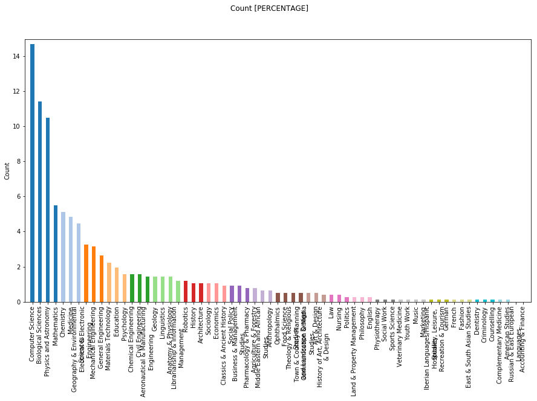

```python
_ = get_plot(perc_to_count, "multiple choices")
```

# Section: 3

## Group of question: prevEmp

### Where was your previous job based?

```python
v_to_count, filename  = get_count(df, ['prevEmp1. Where was your previous job based?'], "one choice", "./../survey_creation/uk_17/listAnswers/type_organisation.csv", "False", "./uk_2017/output/")
```

```python
perc_to_count = get_percentage(v_to_count, filename)
```

```python
display_side_by_side(v_to_count,perc_to_count)
```

|  | Where was your previous job based? |
| --- | --- |
| University | 121 |
| Private company | 64 |
| This is my first job | 27 |
| National laboratory | 16 |
| Government | 8 |
| Other | 8 |
| NGO | 2 |
| NaN | 7 |

|  | Where was your previous job based? [PERCENTAGE] |
| --- | --- |
| University | 49.19 |
| Private company | 26.02 |
| This is my first job | 10.98 |
| National laboratory | 6.50 |
| Government | 3.25 |
| Other | 3.25 |
| NGO | 0.81 |

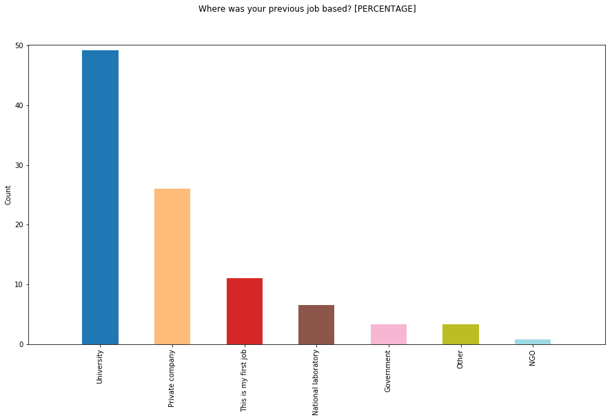

```python
_ = get_plot(perc_to_count, "one choice")
```

### Rank the following factors dependent on how strongly they influenced your decision to accept your current position

```python
v_to_count, filename  = get_count(df, ['prevEmp2[1]. Rank the following factors dependent on how strongly they influenced your decision to accept your current position [Rank 1]', 'prevEmp2[2]. Rank the following factors dependent on how strongly they influenced your decision to accept your current position [Rank 2]', 'prevEmp2[3]. Rank the following factors dependent on how strongly they influenced your decision to accept your current position [Rank 3]', 'prevEmp2[4]. Rank the following factors dependent on how strongly they influenced your decision to accept your current position [Rank 4]', 'prevEmp2[5]. Rank the following factors dependent on how strongly they influenced your decision to accept your current position [Rank 5]', 'prevEmp2[6]. Rank the following factors dependent on how strongly they influenced your decision to accept your current position [Rank 6]', 'prevEmp2[7]. Rank the following factors dependent on how strongly they influenced your decision to accept your current position [Rank 7]', 'prevEmp2[8]. Rank the following factors dependent on how strongly they influenced your decision to accept your current position [Rank 8]'], "ranking", "./../survey_creation/uk_17/listAnswers/reason_leave_job.csv", "False", "./uk_2017/output/")
```

```python
perc_to_count = get_percentage(v_to_count, filename)
```

```python
display_side_by_side(v_to_count,perc_to_count)
```

|  | Rank 1 | Rank 2 | Rank 3 | Rank 4 | Rank 5 | Rank 6 | Rank 7 | Rank 8 |
| --- | --- | --- | --- | --- | --- | --- | --- | --- |
| Desire to work in a research environment | 55 | 39 | 38 | 30 | 15 | 6 | 5 | 2.0 |
| Desire to advance research | 38 | 38 | 41 | 21 | 24 | 15 | 9 | NaN |
| Opportunity to develop software | 32 | 33 | 26 | 25 | 24 | 10 | 12 | 10.0 |
| I want to learn new skills | 27 | 28 | 23 | 31 | 23 | 20 | 11 | 6.0 |
| Freedom to choose own working practices | 23 | 19 | 28 | 22 | 21 | 18 | 20 | 6.0 |
| Opportunity for career advancement | 20 | 23 | 16 | 14 | 14 | 18 | 16 | 17.0 |
| Ability to work across disciplines | 15 | 31 | 27 | 21 | 17 | 21 | 6 | 8.0 |
| Flexible working hours | 14 | 14 | 13 | 27 | 23 | 19 | 16 | 23.0 |
| The salary | 9 | 5 | 9 | 15 | 13 | 16 | 27 | 20.0 |
| NaN | 20 | 23 | 32 | 47 | 79 | 110 | 131 | 161.0 |

|  | Rank 1 | Rank 2 | Rank 3 | Rank 4 | Rank 5 | Rank 6 | Rank 7 | Rank 8 |
| --- | --- | --- | --- | --- | --- | --- | --- | --- |
| Desire to work in a research environment | 28.95 | 20.53 | 20.00 | 15.79 | 7.89 | 3.16 | 2.63 | 1.05 |
| Desire to advance research | 20.43 | 20.43 | 22.04 | 11.29 | 12.90 | 8.06 | 4.84 | NaN |
| Opportunity to develop software | 18.60 | 19.19 | 15.12 | 14.53 | 13.95 | 5.81 | 6.98 | 5.81 |
| I want to learn new skills | 15.98 | 16.57 | 13.61 | 18.34 | 13.61 | 11.83 | 6.51 | 3.55 |
| Freedom to choose own working practices | 14.65 | 12.10 | 17.83 | 14.01 | 13.38 | 11.46 | 12.74 | 3.82 |
| Opportunity for career advancement | 14.49 | 16.67 | 11.59 | 10.14 | 10.14 | 13.04 | 11.59 | 12.32 |
| Ability to work across disciplines | 10.27 | 21.23 | 18.49 | 14.38 | 11.64 | 14.38 | 4.11 | 5.48 |
| Flexible working hours | 9.40 | 9.40 | 8.72 | 18.12 | 15.44 | 12.75 | 10.74 | 15.44 |
| The salary | 7.89 | 4.39 | 7.89 | 13.16 | 11.40 | 14.04 | 23.68 | 17.54 |

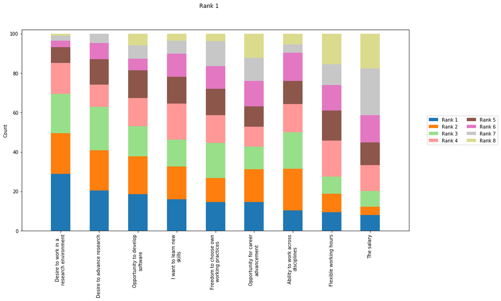

```python
_ = get_plot(perc_to_count, "ranking")
```

# Section: 4

## Group of question: currentWork

### Do you always work with the same researcher(s), or do you regularly change the researcher(s) you work with?

```python
v_to_count, filename  = get_count(df, ['currentWork1. Do you always work with the same researcher(s), or do you regularly change the researcher(s) you work with?'], "one choice", "./../survey_creation/uk_17/listAnswers/work_researchers.csv", "False", "./uk_2017/output/")
```

```python
perc_to_count = get_percentage(v_to_count, filename)
```

```python
display_side_by_side(v_to_count,perc_to_count)
```

|  | Do you always work with the same researcher(s), or do you regularly change the researcher(s) you work with? |
| --- | --- |
| Regularly change researcher(s) | 122 |
| Same researcher(s) | 113 |
| NaN | 18 |

|  | Do you always work with the same researcher(s), or do you regularly change the researcher(s) you work with? [PERCENTAGE] |
| --- | --- |
| Regularly change researcher(s) | 51.91 |
| Same researcher(s) | 48.09 |

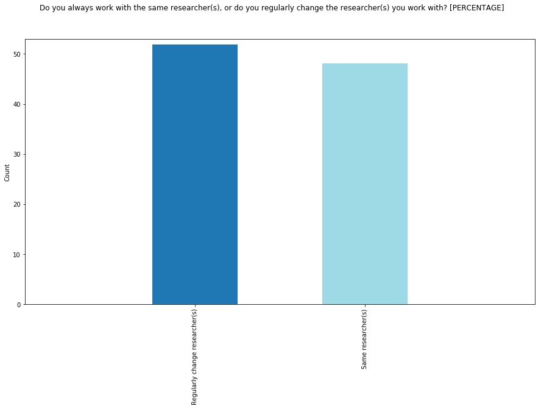

```python
_ = get_plot(perc_to_count, "one choice")
```

### Do you work for a Research Software Group?

```python
v_to_count, filename  = get_count(df, ['currentWork2. Do you work for a Research Software Group?'], "y/n/na", "./../survey_creation/uk_17/listAnswers/.csv", "False", "./uk_2017/output/")
```

```python
perc_to_count = get_percentage(v_to_count, filename)
```

```python
display_side_by_side(v_to_count,perc_to_count)
```

|  | Yes | No | nan |
| --- | --- | --- | --- |
| Do you work for a Research Software Group? | 59 | 58 | 136 |

|  | Yes | No |
| --- | --- | --- |
| Do you work for a Research Software Group? [PERCENTAGE] | 50.43 | 49.57 |

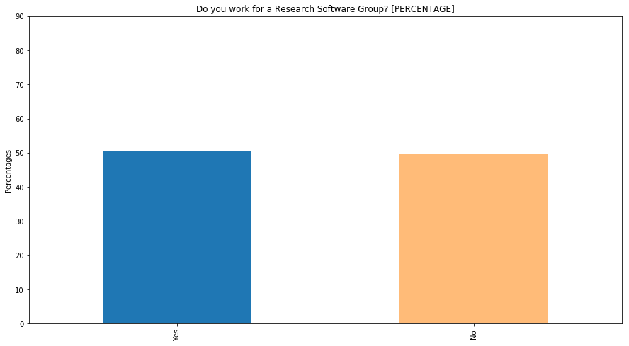

```python
_ = get_plot(perc_to_count, "y/n/na")
```

## Group of question: paper

### Has your software contributed to research that has been published in a journal or at a conference?; In general, when your software contributes to a paper, are you acknowledged in that paper?; Are you generally named as the main author of the paper?; Are you generally named as a co-author of the paper?; Are you generally acknowledged in the main text of the paper?

```python
v_to_count, filename  = get_count(df, ['paper1. Has your software contributed to research that has been published in a journal or at a conference?', 'paper2. In general, when your software contributes to a paper, are you acknowledged in that paper?', 'paper3. Are you generally named as the main author of the paper?', 'paper4. Are you generally named as a co-author of the paper?', 'paper5. Are you generally acknowledged in the main text of the paper?'], "y/n/na", "./../survey_creation/uk_17/listAnswers/.csv", "False", "./uk_2017/output/")
```

```python
perc_to_count = get_percentage(v_to_count, filename)
```

```python
display_side_by_side(v_to_count,perc_to_count)
```

|  | Yes | No | nan |
| --- | --- | --- | --- |
| paper1. Has your software contributed to research that has been published in a journal or at a conference? | 199 | 20 | 34 |
| paper2. In general, when your software contributes to a paper, are you acknowledged in that paper? | 139 | 40 | 74 |
| paper3. Are you generally named as the main author of the paper? | 49 | 86 | 118 |
| paper4. Are you generally named as a co-author of the paper? | 76 | 12 | 165 |
| paper5. Are you generally acknowledged in the main text of the paper? | 11 | 1 | 241 |

|  | Yes | No |
| --- | --- | --- |
| paper1. Has your software contributed to research that has been published in a journal or at a conference? | 90.87 | 9.13 |
| paper2. In general, when your software contributes to a paper, are you acknowledged in that paper? | 77.65 | 22.35 |
| paper3. Are you generally named as the main author of the paper? | 36.30 | 63.70 |
| paper4. Are you generally named as a co-author of the paper? | 86.36 | 13.64 |
| paper5. Are you generally acknowledged in the main text of the paper? | 91.67 | 8.33 |

[output not shown]

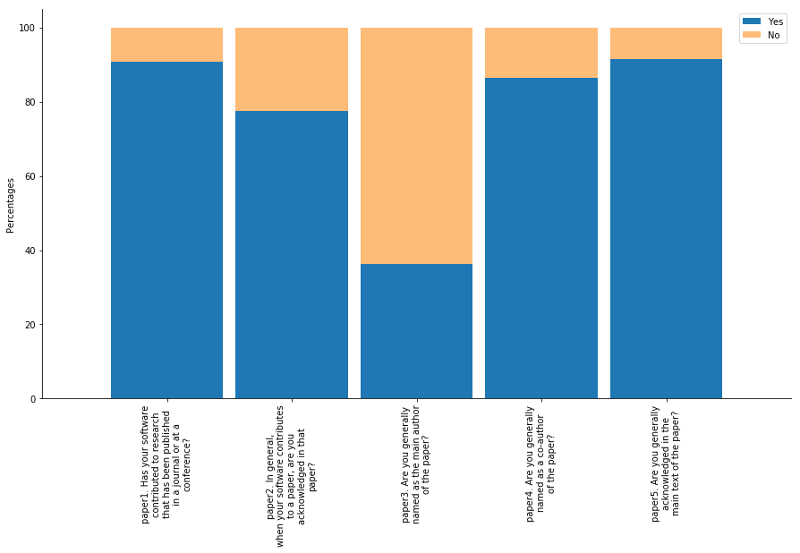

```python
_ = get_plot(perc_to_count, "y/n/na")
```

## Group of question: conf

### Have you ever presented your software work at a conference or workshop?

```python
v_to_count, filename  = get_count(df, ['conf1can. Have you ever presented your software work at a conference or workshop?'], "y/n/na", "./../survey_creation/uk_17/listAnswers/.csv", "False", "./uk_2017/output/")
```

```python
perc_to_count = get_percentage(v_to_count, filename)
```

```python
display_side_by_side(v_to_count,perc_to_count)
```

|  | Yes | No | nan |
| --- | --- | --- | --- |
| Have you ever presented your software work at a conference or workshop? | 134 | 101 | 18 |

|  | Yes | No |
| --- | --- | --- |
| Have you ever presented your software work at a conference or workshop? [PERCENTAGE] | 57.02 | 42.98 |

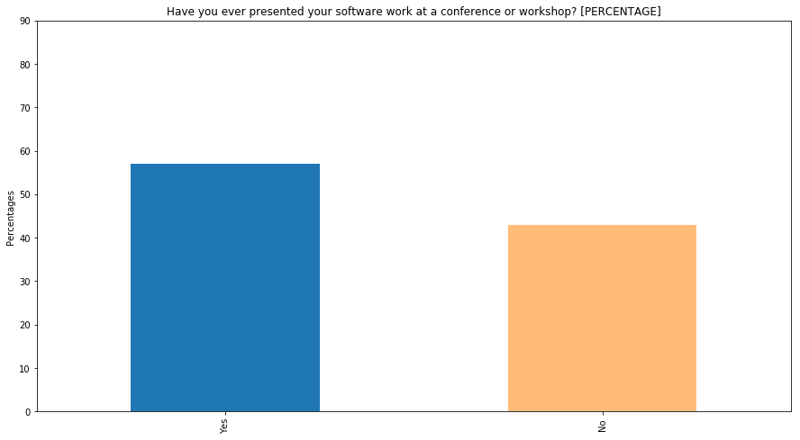

```python
_ = get_plot(perc_to_count, "y/n/na")
```

### Which conference(s)/workshop(s)

## Group of question: proj

### How many software projects are you currently involved in?

```python
v_to_count, filename  = get_count(df, ['proj1can. How many software projects are you currently involved with?'], "freenumeric", "./../survey_creation/uk_17/listAnswers/.csv", "False", "./uk_2017/output/")
```

```python
perc_to_count = get_percentage(v_to_count, filename)
```

```python
display_side_by_side(v_to_count,perc_to_count)
```

|  | How many software projects are you currently involved with? |
| --- | --- |
| 0 | 3.0 |
| 1 | 5.0 |
| 2 | NaN |
| 3 | 5.0 |
| 4 | 5.0 |
| 5 | 4.0 |
| 6 | 3.0 |
| 7 | 2.0 |
| 8 | 2.0 |
| 9 | 2.0 |
| 10 | NaN |
| 11 | 5.0 |
| 12 | 2.0 |
| 13 | 1.0 |
| 14 | 1.0 |
| 15 | 3.0 |
| 16 | 5.0 |
| 17 | 2.0 |
| 18 | 6.0 |
| 19 | 3.0 |
| 20 | 1.0 |
| 21 | 2.0 |
| 22 | 4.0 |
| 23 | 3.0 |
| 24 | 5.0 |
| 25 | 2.0 |
| 26 | 2.0 |
| 27 | 3.0 |
| 28 | 3.0 |
| 29 | 5.0 |

[output cut: 223 more lines]

[output not shown]

[output cut: 223 more lines]

```
       How many software projects are you currently involved with?
count                                         222.000000
mean                                            3.959459
std                                             4.226952
min                                             0.000000
25%                                             2.000000
50%                                             3.000000
75%                                             5.000000
max                                            50.000000
```

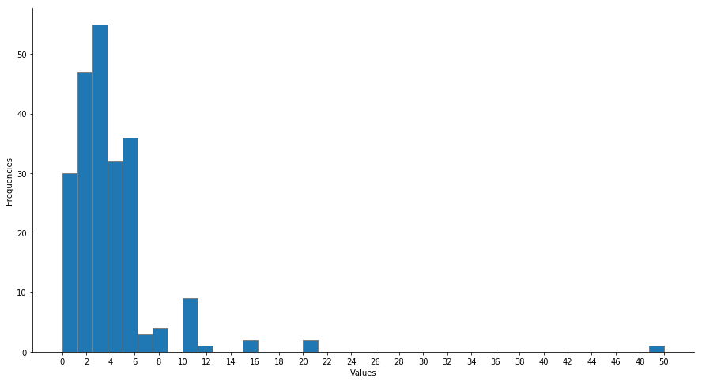

```python
_ = get_plot(v_to_count, "freenumeric")
```

### In general, what sort of testing do you conduct on your software? (check all that apply)

```python
v_to_count, filename  = get_count(df, ['proj4can[SQ001]. In general, what sort of testing do you conduct on your software? (check all that apply) [No formal testing]', 'proj4can[SQ002]. In general, what sort of testing do you conduct on your software? (check all that apply) [Developers conduct testing]', 'proj4can[SQ003]. In general, what sort of testing do you conduct on your software? (check all that apply) [Test engineers conduct testing]', 'proj4can[SQ004]. In general, what sort of testing do you conduct on your software? (check all that apply) [Users conduct testing]'], "multiple choices", "./../survey_creation/uk_17/listAnswers/testing.csv", "False", "./uk_2017/output/")
```

```python
perc_to_count = get_percentage(v_to_count, filename)
```

```python
display_side_by_side(v_to_count,perc_to_count)
```

|  | Count |
| --- | --- |
| Developers conduct testing | 202 |
| Users conduct testing | 99 |
| No formal testing | 37 |
| Test engineers conduct testing | 18 |

|  | Count [PERCENTAGE] |
| --- | --- |
| Developers conduct testing | 56.74 |
| Users conduct testing | 27.81 |
| No formal testing | 10.39 |
| Test engineers conduct testing | 5.06 |

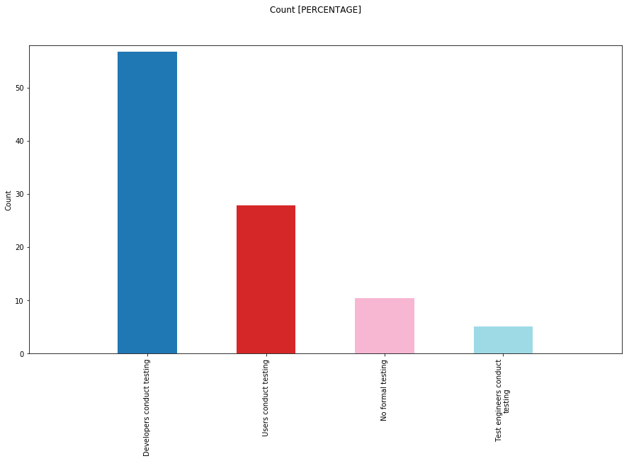

```python
_ = get_plot(perc_to_count, "multiple choices")
```

## Group of question: stability

### What is the bus factor of your most important software project?

```python
v_to_count, filename  = get_count(df, ['stability1. What is the bus factor of your most important software project?'], "likert", "./../survey_creation/uk_17/listAnswers/bus_factor.csv", "True", "./uk_2017/output/")
```

```python
display(v_to_count)
```

|  | 1 | 2 | 3 | 4 | 5+ |
| --- | --- | --- | --- | --- | --- |
| What is the bus factor of your most important software project? | 99 | 72 | 29 | 8 | 25 |

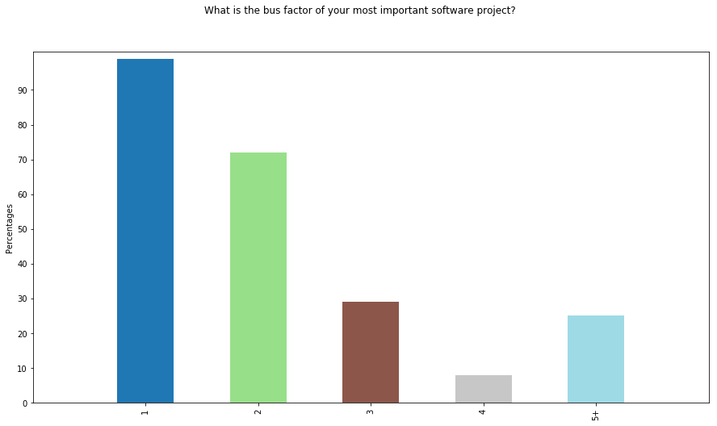

```python
_ = get_plot(v_to_count, "likert")
```

### Is there a technical hand-over plan for your most important software project?

```python
v_to_count, filename  = get_count(df, ['stability2. Is there a technical handover plan for your most important software project?'], "y/n/na", "./../survey_creation/uk_17/listAnswers/.csv", "False", "./uk_2017/output/")
```

```python
perc_to_count = get_percentage(v_to_count, filename)
```

```python
display_side_by_side(v_to_count,perc_to_count)
```

|  | Yes | No | nan |
| --- | --- | --- | --- |
| Is there a technical handover plan for your most important software project? | 61 | 173 | 19 |

|  | Yes | No |
| --- | --- | --- |
| Is there a technical handover plan for your most important software project? [PERCENTAGE] | 26.07 | 73.93 |

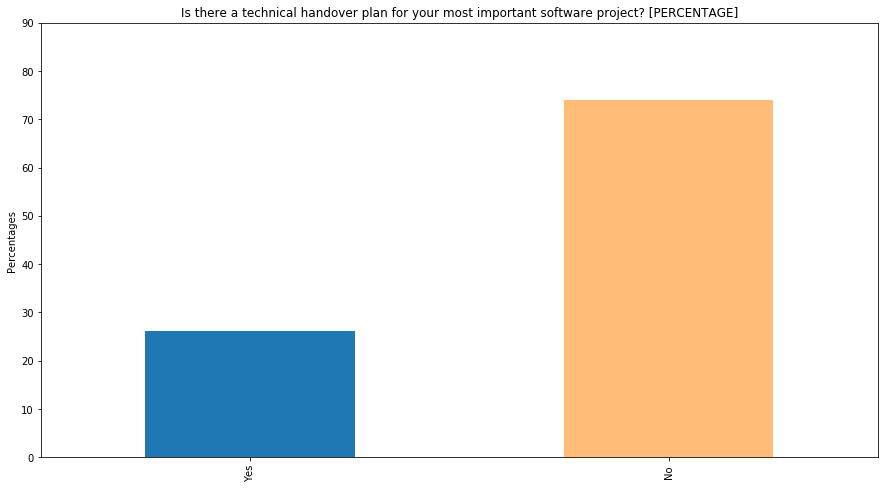

```python
_ = get_plot(perc_to_count, "y/n/na")
```

## Group of question: open

### Have you ever released your software under an open-source licence?

```python
v_to_count, filename  = get_count(df, ['open01can. Have you ever released your software under an open-source licence?'], "y/n/na", "./../survey_creation/uk_17/listAnswers/.csv", "False", "./uk_2017/output/")
```

```python
perc_to_count = get_percentage(v_to_count, filename)
```

```python
display_side_by_side(v_to_count,perc_to_count)
```

|  | Yes | No | nan |
| --- | --- | --- | --- |
| Have you ever released your software under an open-source licence? | 158 | 76 | 19 |

|  | Yes | No |
| --- | --- | --- |
| Have you ever released your software under an open-source licence? [PERCENTAGE] | 67.52 | 32.48 |

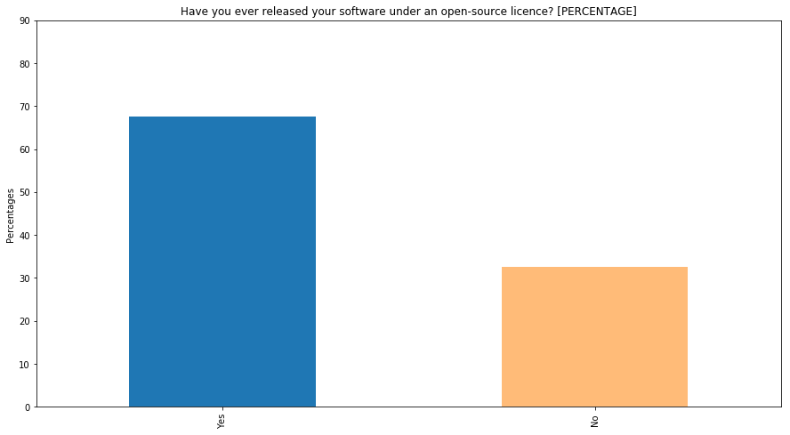

```python
_ = get_plot(perc_to_count, "y/n/na")
```

### How often do you release the software projects you've worked on under an open-source licence?

```python
v_to_count, filename  = get_count(df, ["open1can[A5]. How often do you release the software projects you've worked on under an open-source licence? []"], "likert", "./../survey_creation/uk_17/listAnswers/likert_time_10.csv", "False", "./uk_2017/output/")
```

```python
display(v_to_count)
```

| How often do you release the software projects you've worked on under an open-source licence? [] |
| --- |

```python
_ = get_plot(v_to_count, "likert")
```

[output not shown]

### Have you ever used a Digital Object Identifier (DOI) to identify your software?

```python
v_to_count, filename  = get_count(df, ['open03can. Have you ever used a Digital Object Identifier (DOI) to identify your software?'], "y/n/na", "./../survey_creation/uk_17/listAnswers/.csv", "False", "./uk_2017/output/")
```

```python
perc_to_count = get_percentage(v_to_count, filename)
```

```python
display_side_by_side(v_to_count,perc_to_count)
```

|  | Yes | No | nan |
| --- | --- | --- | --- |
| Have you ever used a Digital Object Identifier (DOI) to identify your software? | 52 | 182 | 19 |

|  | Yes | No |
| --- | --- | --- |
| Have you ever used a Digital Object Identifier (DOI) to identify your software? [PERCENTAGE] | 22.22 | 77.78 |

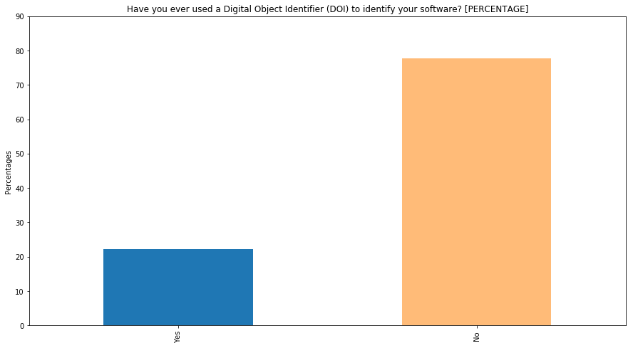

```python
_ = get_plot(perc_to_count, "y/n/na")
```

### How often do you associate your software with a Digital Object Identifier (DOI)?

```python
v_to_count, filename  = get_count(df, ['open3can[SQ001]. How often do you associate your software with a Digital Object Identifier (DOI)? []'], "likert", "./../survey_creation/uk_17/listAnswers/likert_time_10.csv", "False", "./uk_2017/output/")
```

```python
display(v_to_count)
```

| How often do you associate your software with a Digital Object Identifier (DOI)? [] |
| --- |

```python
_ = get_plot(v_to_count, "likert")
```

[output not shown]

## Group of question: train

### Have you ever trained researchers in computational techniques?

```python
v_to_count, filename  = get_count(df, ['train1. Have you ever trained researchers in computational techniques?'], "y/n/na", "./../survey_creation/uk_17/listAnswers/.csv", "False", "./uk_2017/output/")
```

```python
perc_to_count = get_percentage(v_to_count, filename)
```

```python
display_side_by_side(v_to_count,perc_to_count)
```

|  | Yes | No | nan |
| --- | --- | --- | --- |
| Have you ever trained researchers in computational techniques? | 152 | 82 | 19 |

|  | Yes | No |
| --- | --- | --- |
| Have you ever trained researchers in computational techniques? [PERCENTAGE] | 64.96 | 35.04 |

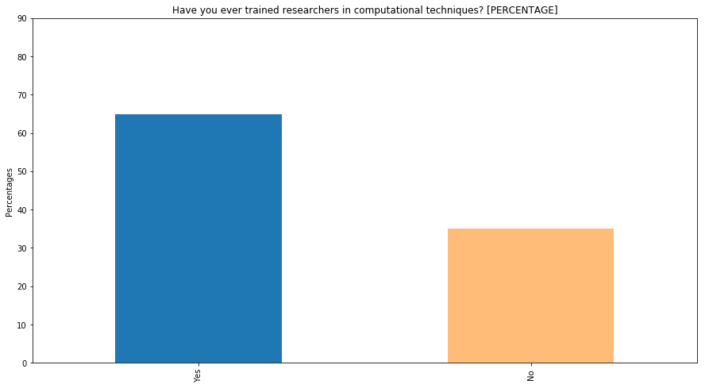

```python
_ = get_plot(perc_to_count, "y/n/na")
```

### On average, how many times a year do you take part in providing training?

```python
v_to_count, filename  = get_count(df, ['train2. On average, how many times a year do you take part in providing training?'], "freenumeric", "./../survey_creation/uk_17/listAnswers/.csv", "False", "./uk_2017/output/")
```

```python
perc_to_count = get_percentage(v_to_count, filename)
```

```python
display_side_by_side(v_to_count,perc_to_count)
```

|  | On average, how many times a year do you take part in providing training? |
| --- | --- |
| 0 | NaN |
| 1 | NaN |
| 2 | NaN |
| 3 | 4.0 |
| 4 | NaN |
| 5 | NaN |
| 6 | NaN |
| 7 | NaN |
| 8 | 2.0 |
| 9 | NaN |
| 10 | 15.0 |
| 11 | NaN |
| 12 | 2.0 |
| 13 | 3.0 |
| 14 | NaN |
| 15 | NaN |
| 16 | 2.0 |
| 17 | NaN |
| 18 | 1.0 |
| 19 | 3.0 |
| 20 | 2.0 |
| 21 | NaN |
| 22 | NaN |
| 23 | 3.0 |
| 24 | NaN |
| 25 | 3.0 |
| 26 | NaN |
| 27 | 2.0 |
| 28 | NaN |
| 29 | NaN |

[output cut: 223 more lines]

[output not shown]

[output cut: 223 more lines]

```
       On average, how many times a year do you take part in providing training?
count                                         146.000000
mean                                            3.431507
std                                             4.071613
min                                             0.000000
25%                                             2.000000
50%                                             2.000000
75%                                             4.000000
max                                            30.000000
```

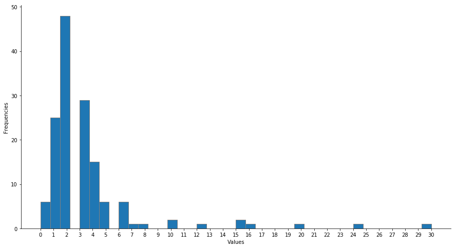

```python
_ = get_plot(v_to_count, "freenumeric")
```

### What training programs are you involved with (comma separated list) (For example, Software Carpentry, local university training, etc.)

## Group of question: fund

### Do you know the source of the funding used to support you and your current, largest project?

```python
v_to_count, filename  = get_count(df, ['fund1. Do you know the source of the funding used to support you and your current, largest project?'], "y/n/na", "./../survey_creation/uk_17/listAnswers/.csv", "False", "./uk_2017/output/")
```

```python
perc_to_count = get_percentage(v_to_count, filename)
```

```python
display_side_by_side(v_to_count,perc_to_count)
```

|  | Yes | No | nan |
| --- | --- | --- | --- |
| Do you know the source of the funding used to support you and your current, largest project? | 199 | 23 | 31 |

|  | Yes | No |
| --- | --- | --- |
| Do you know the source of the funding used to support you and your current, largest project? [PERCENTAGE] | 89.64 | 10.36 |

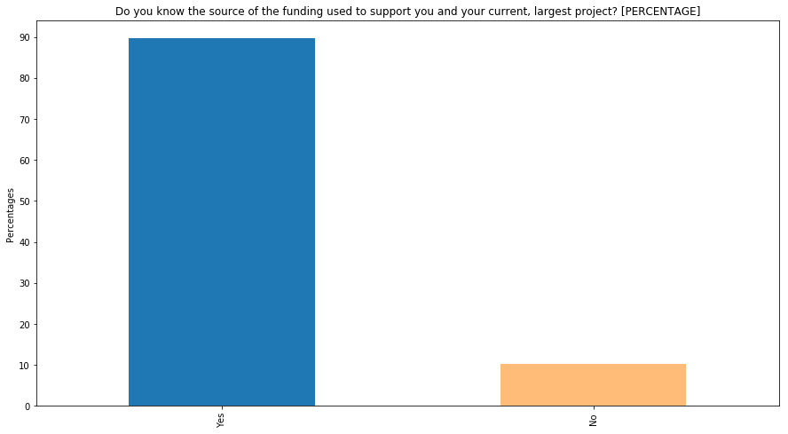

```python
_ = get_plot(perc_to_count, "y/n/na")
```

### Which of the following sources are used to pay for your effort as an RSE/equivalent?

```python
v_to_count, filename  = get_count(df, ['fund2[SQ001]. Which of the following sources are used to pay for your effort as an RSE/equivalent? [I volunteer my time]', 'fund2[SQ002]. Which of the following sources are used to pay for your effort as an RSE/equivalent? [Donation button]', 'fund2[SQ003]. Which of the following sources are used to pay for your effort as an RSE/equivalent? [Crowdfunding (one-time)]', 'fund2[SQ004]. Which of the following sources are used to pay for your effort as an RSE/equivalent? [Crowdfunding (recurring)]', 'fund2[SQ005]. Which of the following sources are used to pay for your effort as an RSE/equivalent? [Books & merchandise]', 'fund2[SQ006]. Which of the following sources are used to pay for your effort as an RSE/equivalent? [Advertising & sponsorships]', 'fund2[SQ007]. Which of the following sources are used to pay for your effort as an RSE/equivalent? [Industry support]', 'fund2[SQ008]. Which of the following sources are used to pay for your effort as an RSE/equivalent? [Consulting & services]', 'fund2[SQ009]. Which of the following sources are used to pay for your effort as an RSE/equivalent? [Grants]', 'fund2[SQ010]. Which of the following sources are used to pay for your effort as an RSE/equivalent? [SaaS]', 'fund2[SQ011]. Which of the following sources are used to pay for your effort as an RSE/equivalent? [Membership]', 'fund2[SQ012]. Which of the following sources are used to pay for your effort as an RSE/equivalent? [Dual license]', 'fund2[SQ013]. Which of the following sources are used to pay for your effort as an RSE/equivalent? [Open core]', 'fund2[SQ014]. Which of the following sources are used to pay for your effort as an RSE/equivalent? [Foundations & consortiums]', 'fund2[SQ015]. Which of the following sources are used to pay for your effort as an RSE/equivalent? [Venture capital]', 'fund2[SQ016]. Which of the following sources are used to pay for your effort as an RSE/equivalent? [Trademark licensing & franchising]'], "multiple choices", "./../survey_creation/uk_17/listAnswers/funding.csv", "False", "./uk_2017/output/")
```

```python
perc_to_count = get_percentage(v_to_count, filename)
```

```python
display_side_by_side(v_to_count,perc_to_count)
```

|  | Count |
| --- | --- |
| Grants | 163 |
| Industry support | 33 |
| I volunteer my time | 27 |
| Consulting & services | 17 |
| Open core | 7 |
| Foundations & consortiums | 6 |
| Trademark licensing & franchising | 3 |
| SaaS | 2 |
| Membership | 2 |
| Dual license | 2 |
| Crowdfunding (one-time) | 1 |
| Books & merchandise | 1 |
| Advertising & sponsorships | 1 |
| Venture capital | 1 |
| Donation button | 0 |
| Crowdfunding (recurring) | 0 |

|  | Count [PERCENTAGE] |
| --- | --- |
| Grants | 61.28 |
| Industry support | 12.41 |
| I volunteer my time | 10.15 |
| Consulting & services | 6.39 |
| Open core | 2.63 |
| Foundations & consortiums | 2.26 |
| Trademark licensing & franchising | 1.13 |
| SaaS | 0.75 |
| Membership | 0.75 |
| Dual license | 0.75 |
| Crowdfunding (one-time) | 0.38 |
| Books & merchandise | 0.38 |
| Advertising & sponsorships | 0.38 |
| Venture capital | 0.38 |
| Donation button | 0.00 |
| Crowdfunding (recurring) | 0.00 |

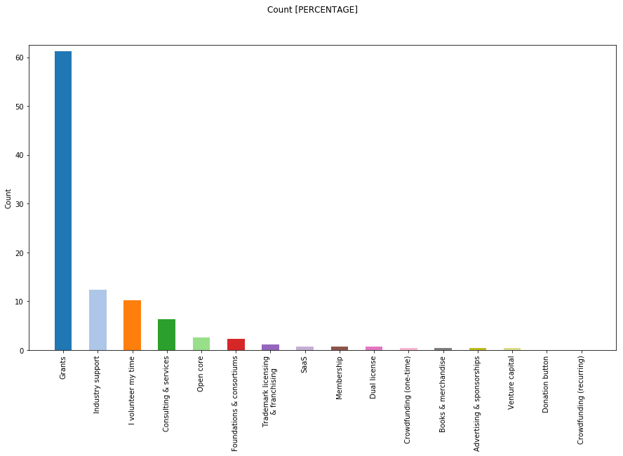

```python
_ = get_plot(perc_to_count, "multiple choices")
```

### Which of the following sources are used to fund your current, largest project?

```python
v_to_count, filename  = get_count(df, ['fund3[SQ001]. Which of the following sources are used to fund your current, largest project? [Volunteers]', 'fund3[SQ002]. Which of the following sources are used to fund your current, largest project? [Donation button]', 'fund3[SQ003]. Which of the following sources are used to fund your current, largest project? [Crowdfunding (one-time)]', 'fund3[SQ004]. Which of the following sources are used to fund your current, largest project? [Crowdfunding (recurring)]', 'fund3[SQ005]. Which of the following sources are used to fund your current, largest project? [Books & merchandise]', 'fund3[SQ006]. Which of the following sources are used to fund your current, largest project? [Advertising & sponsorships]', 'fund3[SQ007]. Which of the following sources are used to fund your current, largest project? [Industry support]', 'fund3[SQ008]. Which of the following sources are used to fund your current, largest project? [Consulting & services]', 'fund3[SQ009]. Which of the following sources are used to fund your current, largest project? [Grants]', 'fund3[SQ010]. Which of the following sources are used to fund your current, largest project? [SaaS]', 'fund3[SQ011]. Which of the following sources are used to fund your current, largest project? [Membership]', 'fund3[SQ012]. Which of the following sources are used to fund your current, largest project? [Dual license]', 'fund3[SQ013]. Which of the following sources are used to fund your current, largest project? [Open core]', 'fund3[SQ014]. Which of the following sources are used to fund your current, largest project? [Foundations & consortiums]', 'fund3[SQ015]. Which of the following sources are used to fund your current, largest project? [Venture capital]', 'fund3[SQ016]. Which of the following sources are used to fund your current, largest project? [Trademark licensing & franchising]'], "multiple choices", "./../survey_creation/uk_17/listAnswers/funding.csv", "False", "./uk_2017/output/")
```

```python
perc_to_count = get_percentage(v_to_count, filename)
```

```python
display_side_by_side(v_to_count,perc_to_count)
```

|  | Count |
| --- | --- |
| Grants | 157 |
| Industry support | 30 |
| Volunteers | 15 |
| Consulting & services | 8 |
| Foundations & consortiums | 5 |
| Membership | 2 |
| Dual license | 2 |
| Open core | 2 |
| Trademark licensing & franchising | 2 |
| Donation button | 1 |
| Crowdfunding (one-time) | 1 |
| SaaS | 1 |
| Venture capital | 1 |
| Crowdfunding (recurring) | 0 |
| Books & merchandise | 0 |
| Advertising & sponsorships | 0 |

|  | Count [PERCENTAGE] |
| --- | --- |
| Grants | 69.16 |
| Industry support | 13.22 |
| Volunteers | 6.61 |
| Consulting & services | 3.52 |
| Foundations & consortiums | 2.20 |
| Membership | 0.88 |
| Dual license | 0.88 |
| Open core | 0.88 |
| Trademark licensing & franchising | 0.88 |
| Donation button | 0.44 |
| Crowdfunding (one-time) | 0.44 |
| SaaS | 0.44 |
| Venture capital | 0.44 |
| Crowdfunding (recurring) | 0.00 |
| Books & merchandise | 0.00 |
| Advertising & sponsorships | 0.00 |

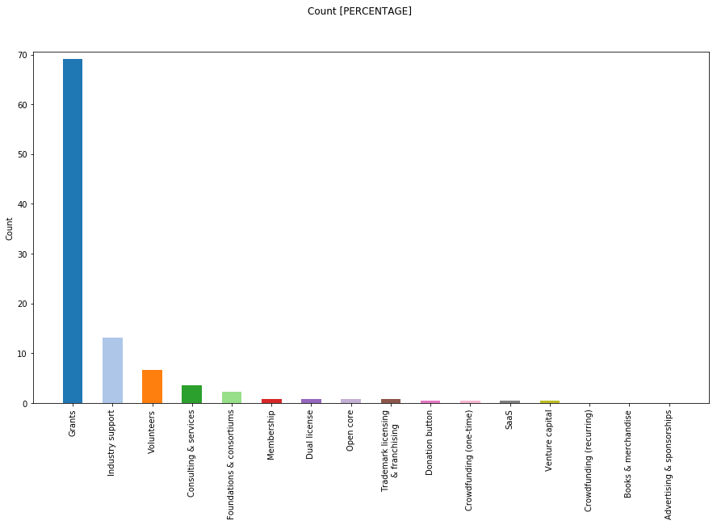

```python
_ = get_plot(perc_to_count, "multiple choices")
```

### Which of the following sources were used to fund your current, largest project three years ago?

```python
v_to_count, filename  = get_count(df, ['fund4[SQ017]. Which of the following sources were used to fund your current, largest project three years ago? [My previous project is less than 3 years old]', 'fund4[SQ001]. Which of the following sources were used to fund your current, largest project three years ago? [Volunteers]', 'fund4[SQ002]. Which of the following sources were used to fund your current, largest project three years ago? [Donation button]', 'fund4[SQ003]. Which of the following sources were used to fund your current, largest project three years ago? [Crowdfunding (one-time)]', 'fund4[SQ004]. Which of the following sources were used to fund your current, largest project three years ago? [Crowdfunding (recurring)]', 'fund4[SQ005]. Which of the following sources were used to fund your current, largest project three years ago? [Books & merchandise]', 'fund4[SQ006]. Which of the following sources were used to fund your current, largest project three years ago? [Advertising & sponsorships]', 'fund4[SQ007]. Which of the following sources were used to fund your current, largest project three years ago? [Industry support]', 'fund4[SQ008]. Which of the following sources were used to fund your current, largest project three years ago? [Consulting & services]', 'fund4[SQ009]. Which of the following sources were used to fund your current, largest project three years ago? [Grants]', 'fund4[SQ010]. Which of the following sources were used to fund your current, largest project three years ago? [SaaS]', 'fund4[SQ011]. Which of the following sources were used to fund your current, largest project three years ago? [Membership]', 'fund4[SQ012]. Which of the following sources were used to fund your current, largest project three years ago? [Dual license]', 'fund4[SQ013]. Which of the following sources were used to fund your current, largest project three years ago? [Open core]', 'fund4[SQ014]. Which of the following sources were used to fund your current, largest project three years ago? [Foundations & consortiums]', 'fund4[SQ015]. Which of the following sources were used to fund your current, largest project three years ago? [Venture capital]', 'fund4[SQ016]. Which of the following sources were used to fund your current, largest project three years ago? [Trademark licensing & franchising]'], "multiple choices", "./../survey_creation/uk_17/listAnswers/funding.csv", "False", "./uk_2017/output/")
```

```python
perc_to_count = get_percentage(v_to_count, filename)
```

```python
display_side_by_side(v_to_count,perc_to_count)
```

|  | Count |
| --- | --- |
| Grants | 127 |
| My previous project is less than 3 years old | 24 |
| Industry support | 23 |
| Volunteers | 10 |
| Consulting & services | 6 |
| Dual license | 2 |
| Open core | 2 |
| Advertising & sponsorships | 1 |
| SaaS | 1 |
| Foundations & consortiums | 1 |
| Venture capital | 1 |
| Trademark licensing & franchising | 1 |
| Books & merchandise | 0 |
| Crowdfunding (recurring) | 0 |
| Crowdfunding (one-time) | 0 |
| Donation button | 0 |
| Membership | 0 |

|  | Count [PERCENTAGE] |
| --- | --- |
| Grants | 63.82 |
| My previous project is less than 3 years old | 12.06 |
| Industry support | 11.56 |
| Volunteers | 5.03 |
| Consulting & services | 3.02 |
| Dual license | 1.01 |
| Open core | 1.01 |
| Advertising & sponsorships | 0.50 |
| SaaS | 0.50 |
| Foundations & consortiums | 0.50 |
| Venture capital | 0.50 |
| Trademark licensing & franchising | 0.50 |
| Books & merchandise | 0.00 |
| Crowdfunding (recurring) | 0.00 |
| Crowdfunding (one-time) | 0.00 |
| Donation button | 0.00 |
| Membership | 0.00 |

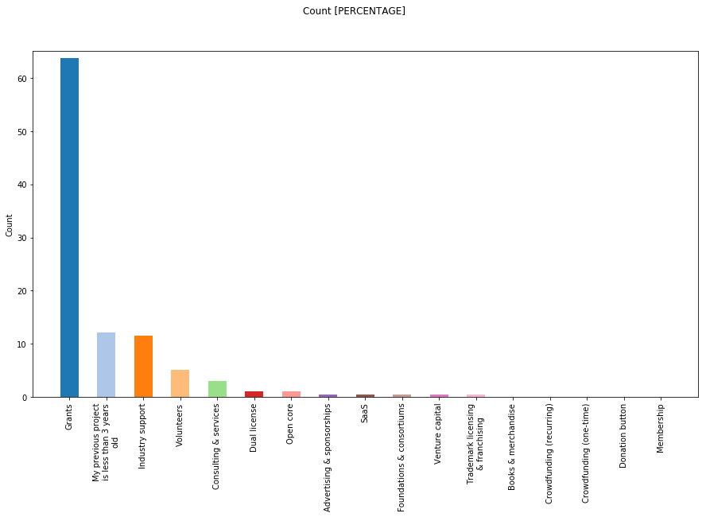

```python
_ = get_plot(perc_to_count, "multiple choices")
```

# Section: 5

## Group of question: perfCheck

### Do you receive sufficient information on the results of your work?; Does your work give you the opportunity to check on how well you are doing your work?; In your work, do you have access to sufficient data and information?; Do you receive sufficient information on the purpose of your work?; Does your work provide you with direct feedback on how well you are doing your work?; Does your supervisor/line manager inform you about how well you are doing your work?; Do your colleagues inform you about how well you are doing your work?

```python
v_to_count, filename  = get_count(df, ['likerttime1[perfCheck1]. Please rate the following propositions. There are no right or wrong answers [Do you receive sufficient information on the results of your work?]', 'likerttime1[perfCheck2]. Please rate the following propositions. There are no right or wrong answers [Do you get the opportunity to check on how well you are doing your work?]', 'likerttime1[perfCheck3]. Please rate the following propositions. There are no right or wrong answers [Do you have access to sufficient data and information to do your work?]', 'likertime2[perfCheck4]. Please rate the following propositions. There are no right or wrong answers [Do you receive sufficient information on the purpose of your work?]', 'likertime2[perfCheck5]. Please rate the following propositions. There are no right or wrong answers [Does your work provide you with direct feedback on how well you are doing?]', 'likertime2[perfCheck6]. Please rate the following propositions. There are no right or wrong answers [Does your supervisor/line manager inform you about how well you are doing your work?]', 'likerttime1[perfCheck7]. Please rate the following propositions. There are no right or wrong answers [Do your colleagues inform you about how well you are doing your work?]'], "likert", "./../survey_creation/uk_17/listAnswers/likert_time_5.csv", "False", "./uk_2017/output/")
```

```python
display(v_to_count)
```

|  | Never | Sometimes | Often | Very Often | Always |
| --- | --- | --- | --- | --- | --- |
| Do you receive sufficient information on the results of your work? | 5 | 74 | 62 | 51 | 21 |
| Do you get the opportunity to check on how well you are doing your work? | 17 | 90 | 68 | 30 | 8 |
| Do you have access to sufficient data and information to do your work? | 1 | 44 | 62 | 75 | 40 |
| Do you receive sufficient information on the purpose of your work? | 6 | 38 | 73 | 50 | 47 |
| Does your work provide you with direct feedback on how well you are doing? | 15 | 115 | 41 | 29 | 13 |
| Does your supervisor/line manager inform you about how well you are doing your work? | 13 | 97 | 53 | 28 | 16 |
| Do your colleagues inform you about how well you are doing your work? | 20 | 110 | 48 | 32 | 7 |

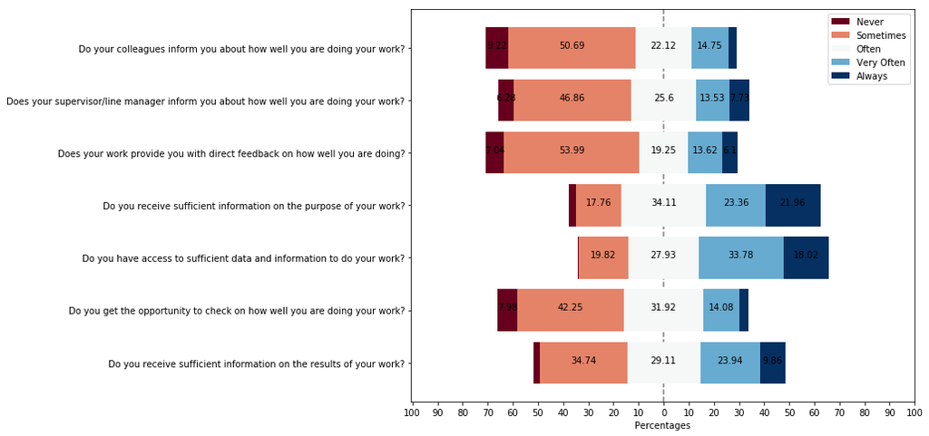

```python
_ = get_plot(v_to_count, "likert")
```

## Group of question: turnOver

### How often do you feel frustrated when not given the opportunity to achieve your personal work-related goals?; How often do you look forward to another day at work?; How often do you consider leaving your job?; How often do dream about getting another job that will better suit your needs?

```python
v_to_count, filename  = get_count(df, ['likertime2[turnOver1]. Please rate the following propositions. There are no right or wrong answers [How often do you feel frustrated when not given the opportunity to achieve your personal work-related goals?]', 'likertime2[turnOver2]. Please rate the following propositions. There are no right or wrong answers [How often do you look forward to another day at work?]', 'likerttime1[turnOver3]. Please rate the following propositions. There are no right or wrong answers [How often do you consider leaving your job?]', 'likerttime1[turnOver4]. Please rate the following propositions. There are no right or wrong answers [How often do you dream about getting another job that will better suit your needs?]'], "likert", "./../survey_creation/uk_17/listAnswers/likert_time_5.csv", "False", "./uk_2017/output/")
```

```python
display(v_to_count)
```

|  | Never | Sometimes | Often | Very Often | Always |
| --- | --- | --- | --- | --- | --- |
| How often do you feel frustrated when not given the opportunity to achieve your personal work-related goals? | 32 | 98 | 41 | 24 | 12 |
| How often do you look forward to another day at work? | 7 | 72 | 74 | 43 | 19 |
| How often do you consider leaving your job? | 45 | 111 | 30 | 24 | 9 |
| How often do you dream about getting another job that will better suit your needs? | 43 | 99 | 23 | 34 | 19 |

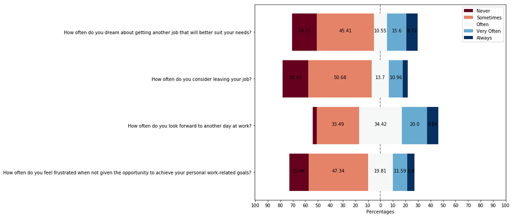

```python
_ = get_plot(v_to_count, "likert")
```

### My current job satisfies my personal needs; I would accept another job at the same compensation level if I was offered it

```python
v_to_count, filename  = get_count(df, ['likertagree1[turnOver5]. Please rate the following propositions. There are no right or wrong answers [My current job satisfies my personal needs]', 'likertagree3[turnOver6]. Please rate the following propositions. There are no right or wrong answers [I would accept another job at the same compensation level if I was offered it]'], "likert", "./../survey_creation/uk_17/listAnswers/likert_agree.csv", "False", "./uk_2017/output/")
```

```python
display(v_to_count)
```

|  | Strongly disagree | Disagree | Neither agree or disagree | Agree | Strongly Agree |
| --- | --- | --- | --- | --- | --- |
| My current job satisfies my personal needs | 9 | 26 | 36 | 113 | 37 |
| I would accept another job at the same compensation level if I was offered it | 27 | 64 | 72 | 33 | 13 |

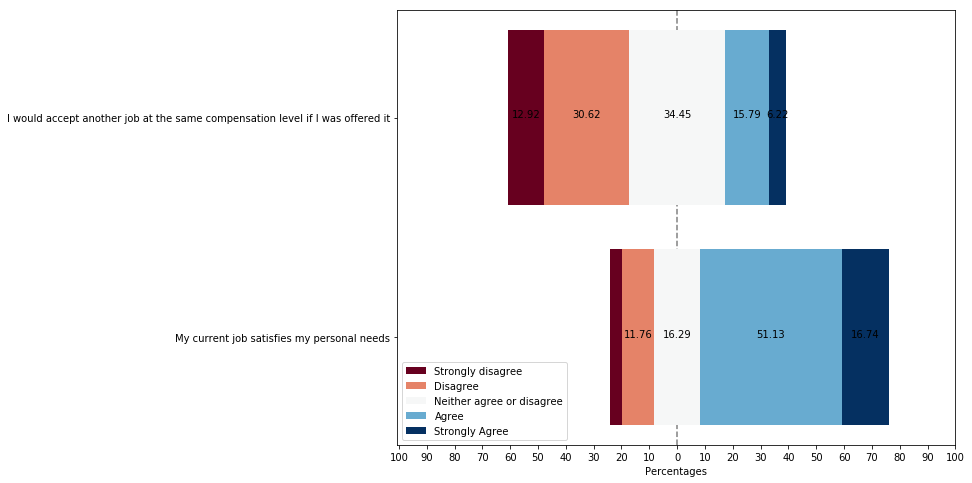

```python
_ = get_plot(v_to_count, "likert")
```

## Group of question: affRec

### I am satisfied with my supervisor/line manager's confidence in me; I am satisfied with a word of thanks from my supervisor/line manager; I am satisfied with the recognition I receive from my supervisor/line manager for doing my job; I am satisfied with the compliments from my supervisor/line manager concerning my work; I am satisfied with the encouragement from my supervisor/line manager while doing my job

```python
v_to_count, filename  = get_count(df, ["likertagree3[affRec1]. Please rate the following propositions. There are no right or wrong answers [I am satisfied with my supervisor/line manager's confidence in me]", 'likertagree2[affRec2]. Please rate the following propositions. There are no right or wrong answers [I am satisfied with a word of thanks from my supervisor/line manager]', 'likertagree2[affRec3]. Please rate the following propositions. There are no right or wrong answers [I am satisfied with the recognition I receive from my supervisor/line manager for doing my job]', 'likertagree1[affRec4]. Please rate the following propositions. There are no right or wrong answers [I am satisfied with the compliments from my supervisor/line manager concerning my work]', 'likertagree3[affRec5]. Please rate the following propositions. There are no right or wrong answers [I am satisfied with the encouragement from my supervisor/line manager while doing my job]'], "likert", "./../survey_creation/uk_17/listAnswers/likert_agree.csv", "False", "./uk_2017/output/")
```

```python
display(v_to_count)
```

|  | Strongly disagree | Disagree | Neither agree or disagree | Agree | Strongly Agree |
| --- | --- | --- | --- | --- | --- |
| I am satisfied with my supervisor/line manager's confidence in me | 6 | 13 | 30 | 105 | 56 |
| I am satisfied with a word of thanks from my supervisor/line manager | 8 | 22 | 58 | 89 | 37 |
| I am satisfied with the recognition I receive from my supervisor/line manager for doing my job | 9 | 31 | 37 | 90 | 51 |
| I am satisfied with the compliments from my supervisor/line manager concerning my work | 8 | 37 | 43 | 101 | 19 |
| I am satisfied with the encouragement from my supervisor/line manager while doing my job | 9 | 33 | 46 | 87 | 34 |

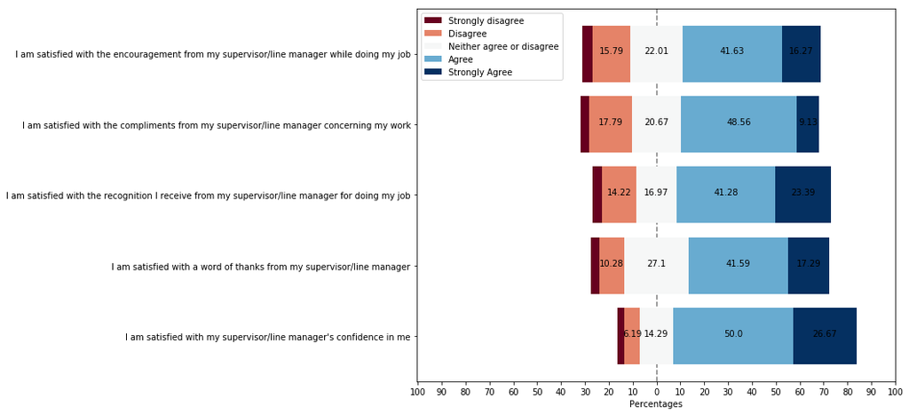

```python
_ = get_plot(v_to_count, "likert")
```

## Group of question: percEmp

### It would not be very difficult for me to get an equivalent job in a different organisation; I can think of a number of organisations that would probably offer me a job; My experience is in demand on the labour market; Given my qualifications and experience, getting a new job would not be very hard at all

```python
v_to_count, filename  = get_count(df, ['likertagree1[percEmp1]. Please rate the following propositions. There are no right or wrong answers [It would not be very difficult for me to get an equivalent job in a different organisation]', 'likertagree2[percEmp2]. Please rate the following propositions. There are no right or wrong answers [I can think of a number of organisations that would probably offer me a job]', 'likertagree1[percEmp3]. Please rate the following propositions. There are no right or wrong answers [My experience is in demand on the labour market]', 'likertagree3[percEmp4]. Please rate the following propositions. There are no right or wrong answers [Given my qualifications and experience, getting a new job would not be very hard at all]'], "likert", "./../survey_creation/uk_17/listAnswers/likert_agree.csv", "False", "./uk_2017/output/")
```

```python
display(v_to_count)
```

|  | Strongly disagree | Disagree | Neither agree or disagree | Agree | Strongly Agree |
| --- | --- | --- | --- | --- | --- |
| It would not be very difficult for me to get an equivalent job in a different organisation | 11 | 39 | 64 | 61 | 36 |
| I can think of a number of organisations that would probably offer me a job | 2 | 14 | 35 | 101 | 69 |
| My experience is in demand on the labour market | 3 | 13 | 37 | 101 | 60 |
| Given my qualifications and experience, getting a new job would not be very hard at all | 8 | 20 | 66 | 75 | 44 |

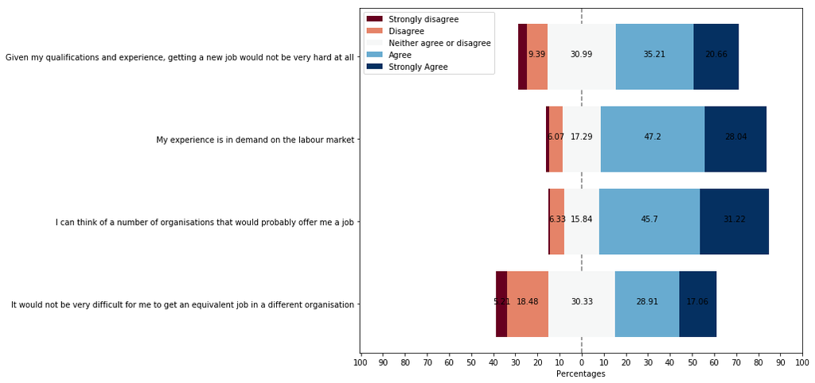

```python
_ = get_plot(v_to_count, "likert")
```

## Group of question: affSat

### I find real enjoyment in my job; Most days I am enthusiastic about my job; I feel fairly well satisfied with my job; I like my job better than the average person

```python
v_to_count, filename  = get_count(df, ['likertagree2[affSat1]. Please rate the following propositions. There are no right or wrong answers [I find real enjoyment in my job]', 'likertagree2[affSat2]. Please rate the following propositions. There are no right or wrong answers [Most days I am enthusiastic about my job]', 'likertagree1[affSat3]. Please rate the following propositions. There are no right or wrong answers [I feel satisfied with my job]', 'likertagree3[affSat4]. Please rate the following propositions. There are no right or wrong answers [I like my job more than average]'], "likert", "./../survey_creation/uk_17/listAnswers/likert_agree.csv", "False", "./uk_2017/output/")
```

```python
display(v_to_count)
```

|  | Strongly disagree | Disagree | Neither agree or disagree | Agree | Strongly Agree |
| --- | --- | --- | --- | --- | --- |
| I find real enjoyment in my job | 4 | 10 | 20 | 95 | 96 |
| Most days I am enthusiastic about my job | 5 | 16 | 37 | 115 | 50 |
| I feel satisfied with my job | 9 | 26 | 40 | 111 | 29 |
| I like my job more than average | 7 | 10 | 41 | 101 | 55 |

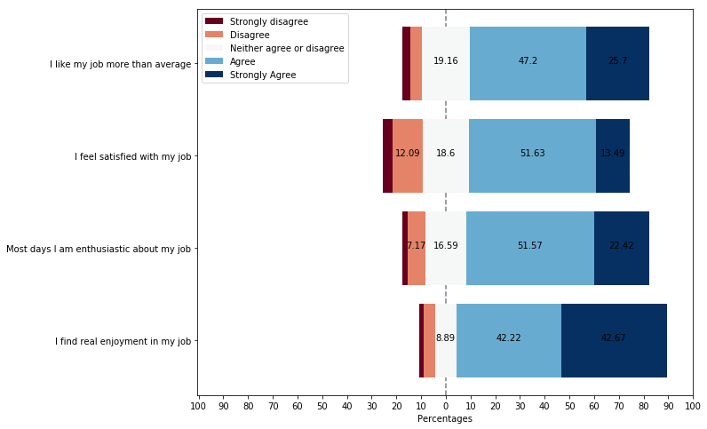

```python
_ = get_plot(v_to_count, "likert")
```

## Group of question: satisGen

### In general, how satisfied are you with Your current position

```python
v_to_count, filename  = get_count(df, ['satisGen1[SQ001]. In general, how satisfied are you with: [Your current position]', 'satisGen1[SQ002]. In general, how satisfied are you with: [Your career]'], "likert", "./../survey_creation/uk_17/listAnswers/likert_satisfied_10.csv", "False", "./uk_2017/output/")
```

```python
display(v_to_count)
```

|  | 0 - Not at all satisfied | 1 | 2 | 3 | 4 | 5 | 6 | 7 | 8 | 9 | 10 - Completely satisfied |
| --- | --- | --- | --- | --- | --- | --- | --- | --- | --- | --- | --- |
| Your current position | 7 | 4 | 6 | 4 | 12 | 18 | 32 | 61 | 44 | 26 | 5 |
| Your career | 4 | 4 | 7 | 14 | 19 | 23 | 37 | 55 | 41 | 12 | 4 |

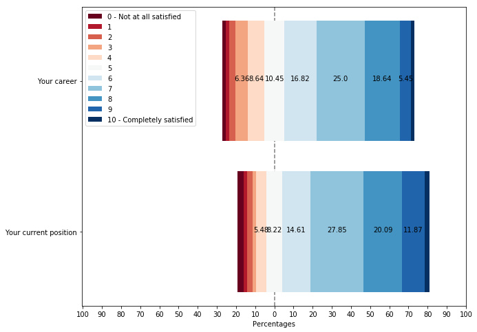

```python
_ = get_plot(v_to_count, "likert")
```

# Section: 6

## Group of question: socio

### Please select your gender

```python
v_to_count, filename  = get_count(df, ['socio2. Please select your gender'], "one choice", "./../survey_creation/uk_17/listAnswers/gender.csv", "False", "./uk_2017/output/")
```

```python
perc_to_count = get_percentage(v_to_count, filename)
```

```python
display_side_by_side(v_to_count,perc_to_count)
```

|  | Please select your gender |
| --- | --- |
| Male | 183 |
| Female | 33 |
| Other | 1 |
| NaN | 36 |

|  | Please select your gender [PERCENTAGE] |
| --- | --- |
| Male | 84.33 |
| Female | 15.21 |
| Other | 0.46 |

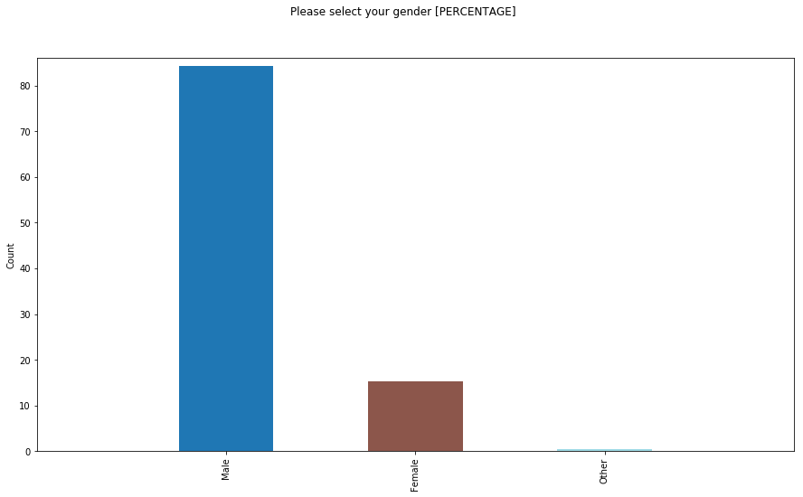

```python
_ = get_plot(perc_to_count, "one choice")
```

### Please select your age

```python
v_to_count, filename  = get_count(df, ['socio3. Please select your age'], "one choice", "./../survey_creation/uk_17/listAnswers/age.csv", "True", "./uk_2017/output/")
```

```python
perc_to_count = get_percentage(v_to_count, filename)
```

```python
display_side_by_side(v_to_count,perc_to_count)
```

|  | Please select your age |
| --- | --- |
| 18 to 24 years | 88 |
| 25 to 34 years | 78 |
| 35 to 44 years | 38 |
| 45 to 54 years | 33 |
| 55 to 64 years | 12 |
| NaN | 4 |

|  | Please select your age [PERCENTAGE] |
| --- | --- |
| 18 to 24 years | 35.34 |
| 25 to 34 years | 31.33 |
| 35 to 44 years | 15.26 |
| 45 to 54 years | 13.25 |
| 55 to 64 years | 4.82 |

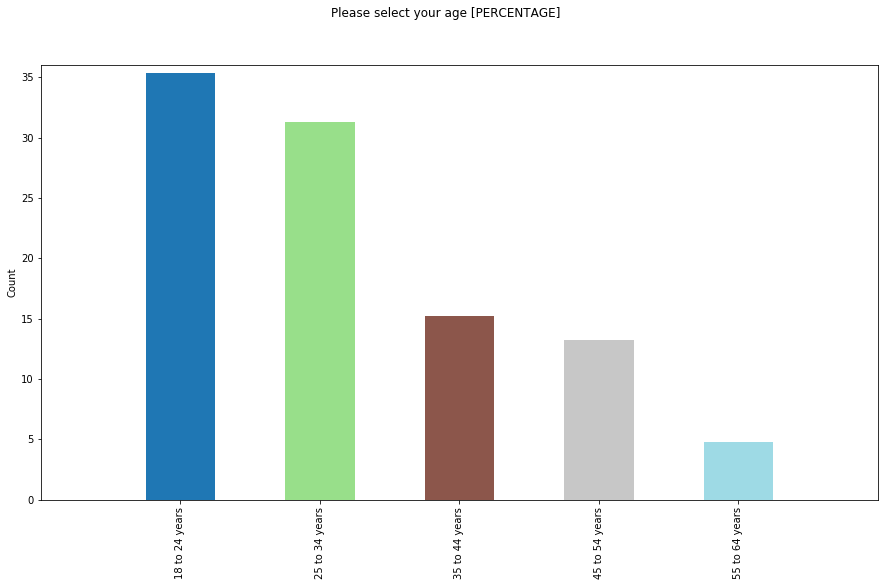

```python
_ = get_plot(perc_to_count, "one choice")
```

### How would you describe your ethnic origin? This refers to people who share the same cultural background and identity, not country of birth or nationality.

```python
v_to_count, filename  = get_count(df, ['socio5. How would you describe your ethnic origin? This refers to people who share the same cultural background and identity, not country of birth or nationality.'], "one choice", "./../survey_creation/uk_17/listAnswers/ethnicity.csv", "False", "./uk_2017/output/")
```

```python
perc_to_count = get_percentage(v_to_count, filename)
```

```python
display_side_by_side(v_to_count,perc_to_count)
```

|  | How would you describe your ethnic origin? This refers to people who share the same cultural background and identity, not country of birth or nationality. |
| --- | --- |
| White: English / Welsh / Scottish / Northern Irish / British | 136 |
| White: Any other White background | 57 |
| Asian / Asian British: Chinese | 5 |
| White: Irish | 3 |
| Other Ethnic group: Any other ethnic group | 3 |
| Black / African / Caribbean / Black Britsh: African | 2 |
| Mixed / Multipe Ethnic groups: Any other Mixed / Multiple ethnic background, | 2 |
| Asian / Asian British: Indian | 1 |
| Mixed / Multipe Ethnic groups: White and Black Caribbean | 1 |
| NaN | 43 |

|  | How would you describe your ethnic origin? This refers to people who share the same cultural background and identity, not country of birth or nationality. [PERCENTAGE] |
| --- | --- |
| White: English / Welsh / Scottish / Northern Irish / British | 64.76 |
| White: Any other White background | 27.14 |
| Asian / Asian British: Chinese | 2.38 |
| White: Irish | 1.43 |
| Other Ethnic group: Any other ethnic group | 1.43 |
| Black / African / Caribbean / Black Britsh: African | 0.95 |
| Mixed / Multipe Ethnic groups: Any other Mixed / Multiple ethnic background, | 0.95 |
| Asian / Asian British: Indian | 0.48 |
| Mixed / Multipe Ethnic groups: White and Black Caribbean | 0.48 |

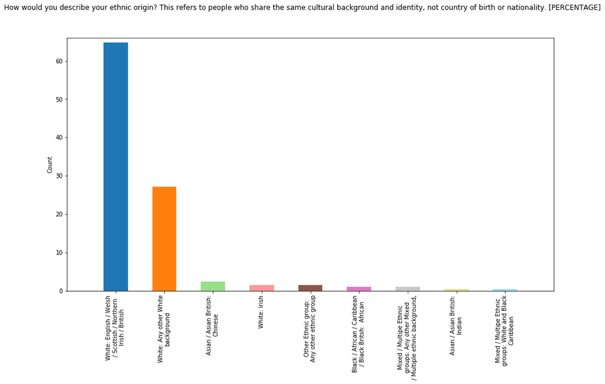

```python
_ = get_plot(perc_to_count, "one choice")
```

### Please select the range of your salary

```python
v_to_count, filename  = get_count(df, ['socio4. Please select the range of your salary'], "one choice", "./../survey_creation/uk_17/listAnswers/salary.csv", "True", "./uk_2017/output/")
```

```python
perc_to_count = get_percentage(v_to_count, filename)
```

```python
display_side_by_side(v_to_count,perc_to_count)
```

|  | Please select the range of your salary |
| --- | --- |
| < £18,031 | 99 |
| ≥ £18,031 and < £24,057 | 56 |
| ≥ £24,057 and < £32,277 | 43 |
| ≥ £32,277 and < £43,325 | 36 |
| ≥ £43,325 and < £58,172 | 8 |
| ≥ £58,172 | 7 |
| NaN | 4 |

|  | Please select the range of your salary [PERCENTAGE] |
| --- | --- |
| < £18,031 | 39.76 |
| ≥ £18,031 and < £24,057 | 22.49 |
| ≥ £24,057 and < £32,277 | 17.27 |
| ≥ £32,277 and < £43,325 | 14.46 |
| ≥ £43,325 and < £58,172 | 3.21 |
| ≥ £58,172 | 2.81 |

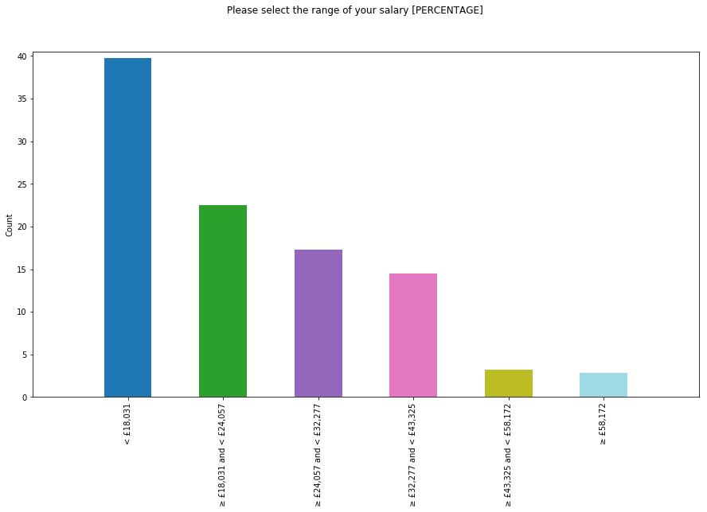

```python
_ = get_plot(perc_to_count, "one choice")
```

## Group of question: disa

### Do you have a condition that is defined as a disability by the Equality Act 2010*

```python
v_to_count, filename  = get_count(df, ['disa1. Do you have a condition that is defined as a disability by the Equality Act 2010*'], "y/n/na", "./../survey_creation/uk_17/listAnswers/.csv", "False", "./uk_2017/output/")
```

```python
perc_to_count = get_percentage(v_to_count, filename)
```

```python
display_side_by_side(v_to_count,perc_to_count)
```

|  | Yes | No | nan |
| --- | --- | --- | --- |
| Do you have a condition that is defined as a disability by the Equality Act 2010* | 10 | 199 | 44 |

|  | Yes | No |
| --- | --- | --- |
| Do you have a condition that is defined as a disability by the Equality Act 2010* [PERCENTAGE] | 4.78 | 95.22 |

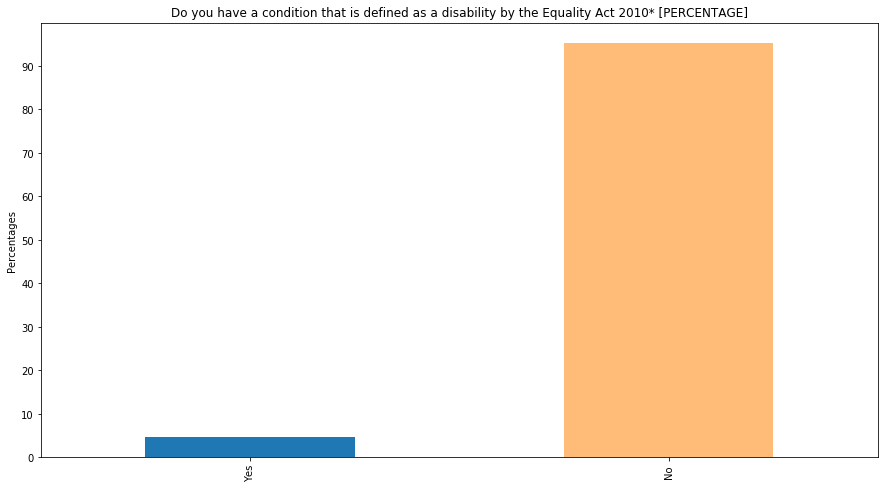

```python
_ = get_plot(perc_to_count, "y/n/na")
```

# Section: 7

## Group of question: tool

### What Operating System do you prefer to use at work?

```python
v_to_count, filename  = get_count(df, ['tool2. What Operating System do you prefer to use at work?'], "one choice", "./../survey_creation/uk_17/listAnswers/os.csv", "False", "./uk_2017/output/")
```

```python
perc_to_count = get_percentage(v_to_count, filename)
```

```python
display_side_by_side(v_to_count,perc_to_count)
```

|  | What Operating System do you prefer to use at work? |
| --- | --- |
| GNU/Linux | 135 |
| OS X | 51 |
| Windows | 33 |
| Other | 2 |
| NaN | 32 |

|  | What Operating System do you prefer to use at work? [PERCENTAGE] |
| --- | --- |
| GNU/Linux | 61.09 |
| OS X | 23.08 |
| Windows | 14.93 |
| Other | 0.90 |

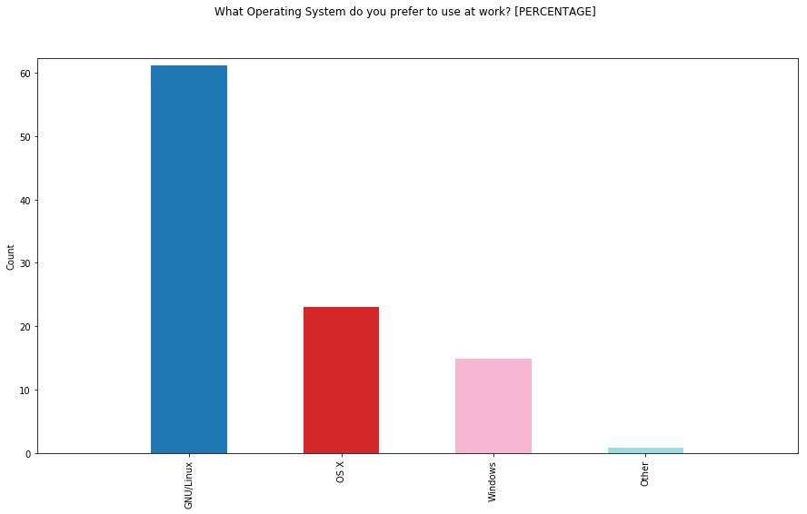

```python
_ = get_plot(perc_to_count, "one choice")
```

### What programming languages do you use at work? (Select as many as apply)

```python
v_to_count, filename  = get_count(df, ['tool4can[SQ001]. What programming languages do you use at work? (Select as many as apply) [Assembly]', 'tool4can[SQ002]. What programming languages do you use at work? (Select as many as apply) [C]', 'tool4can[SQ003]. What programming languages do you use at work? (Select as many as apply) [C#]', 'tool4can[SQ004]. What programming languages do you use at work? (Select as many as apply) [C++]', 'tool4can[SQ005]. What programming languages do you use at work? (Select as many as apply) [Clojure]', 'tool4can[SQ006]. What programming languages do you use at work? (Select as many as apply) [CoffeeScript]', 'tool4can[SQ007]. What programming languages do you use at work? (Select as many as apply) [Common Lisp]', 'tool4can[SQ036]. What programming languages do you use at work? (Select as many as apply) [CUDA]', 'tool4can[SQ008]. What programming languages do you use at work? (Select as many as apply) [Dart]', 'tool4can[SQ009]. What programming languages do you use at work? (Select as many as apply) [Elixir]', 'tool4can[SQ010]. What programming languages do you use at work? (Select as many as apply) [Erlang]', 'tool4can[SQ011]. What programming languages do you use at work? (Select as many as apply) [F#]', 'tool4can[SQ037]. What programming languages do you use at work? (Select as many as apply) [FORTRAN]', 'tool4can[SQ012]. What programming languages do you use at work? (Select as many as apply) [Go]', 'tool4can[SQ013]. What programming languages do you use at work? (Select as many as apply) [Groovy]', 'tool4can[SQ014]. What programming languages do you use at work? (Select as many as apply) [Hack]', 'tool4can[SQ015]. What programming languages do you use at work? (Select as many as apply) [Haskell]', 'tool4can[SQ016]. What programming languages do you use at work? (Select as many as apply) [Java]', 'tool4can[SQ017]. What programming languages do you use at work? (Select as many as apply) [JavaScript]', 'tool4can[SQ018]. What programming languages do you use at work? (Select as many as apply) [Julia]', 'tool4can[SQ019]. What programming languages do you use at work? (Select as many as apply) [Lua]', 'tool4can[SQ038]. What programming languages do you use at work? (Select as many as apply) [Markup languages (HTML, markdown,...)]', 'tool4can[SQ020]. What programming languages do you use at work? (Select as many as apply) [Matlab]', 'tool4can[SQ021]. What programming languages do you use at work? (Select as many as apply) [Objective-C]', 'tool4can[SQ022]. What programming languages do you use at work? (Select as many as apply) [Perl]', 'tool4can[SQ023]. What programming languages do you use at work? (Select as many as apply) [PHP]', 'tool4can[SQ024]. What programming languages do you use at work? (Select as many as apply) [Python]', 'tool4can[SQ025]. What programming languages do you use at work? (Select as many as apply) [R]', 'tool4can[SQ026]. What programming languages do you use at work? (Select as many as apply) [Ruby]', 'tool4can[SQ027]. What programming languages do you use at work? (Select as many as apply) [Rust]', 'tool4can[SQ028]. What programming languages do you use at work? (Select as many as apply) [Scala]', 'tool4can[SQ029]. What programming languages do you use at work? (Select as many as apply) [Smalltalk]', 'tool4can[SQ030]. What programming languages do you use at work? (Select as many as apply) [SQL]', 'tool4can[SQ031]. What programming languages do you use at work? (Select as many as apply) [Swift]', 'tool4can[SQ039]. What programming languages do you use at work? (Select as many as apply) [Unix Shell Scripting]', 'tool4can[SQ032]. What programming languages do you use at work? (Select as many as apply) [TypeScript]', 'tool4can[SQ033]. What programming languages do you use at work? (Select as many as apply) [VB.NET]', 'tool4can[SQ034]. What programming languages do you use at work? (Select as many as apply) [VBA]', 'tool4can[SQ035]. What programming languages do you use at work? (Select as many as apply) [Visual Basic]'], "multiple choices", "./../survey_creation/uk_17/listAnswers/programing_language.csv", "False", "./uk_2017/output/")
```

```python
perc_to_count = get_percentage(v_to_count, filename)
```

```python
display_side_by_side(v_to_count,perc_to_count)
```

|  | Count |
| --- | --- |
| Python | 189 |
| Unix Shell Scripting | 140 |
| Markup languages (HTML, markdown,...) | 113 |
| C++ | 94 |
| C | 92 |
| JavaScript | 85 |
| FORTRAN | 81 |
| SQL | 79 |
| Java | 65 |
| Matlab | 61 |
| R | 57 |
| Perl | 41 |
| PHP | 31 |
| CUDA | 21 |
| C# | 19 |
| Ruby | 14 |
| TypeScript | 9 |
| Groovy | 7 |
| VBA | 7 |
| Visual Basic | 7 |
| Scala | 6 |
| Assembly | 5 |
| Go | 5 |
| Rust | 3 |
| F# | 3 |
| Elixir | 2 |
| CoffeeScript | 2 |
| Objective-C | 2 |
| Julia | 2 |
| Haskell | 2 |
| Erlang | 1 |
| Smalltalk | 1 |
| Swift | 1 |
| VB.NET | 1 |
| Clojure | 1 |
| Lua | 1 |
| Hack | 0 |
| Dart | 0 |
| Common Lisp | 0 |

|  | Count [PERCENTAGE] |
| --- | --- |
| Python | 15.12 |
| Unix Shell Scripting | 11.20 |
| Markup languages (HTML, markdown,...) | 9.04 |
| C++ | 7.52 |
| C | 7.36 |
| JavaScript | 6.80 |
| FORTRAN | 6.48 |
| SQL | 6.32 |
| Java | 5.20 |
| Matlab | 4.88 |
| R | 4.56 |
| Perl | 3.28 |
| PHP | 2.48 |
| CUDA | 1.68 |
| C# | 1.52 |
| Ruby | 1.12 |
| TypeScript | 0.72 |
| Groovy | 0.56 |
| VBA | 0.56 |
| Visual Basic | 0.56 |
| Scala | 0.48 |
| Assembly | 0.40 |
| Go | 0.40 |
| Rust | 0.24 |
| F# | 0.24 |
| Elixir | 0.16 |
| CoffeeScript | 0.16 |
| Objective-C | 0.16 |
| Julia | 0.16 |
| Haskell | 0.16 |
| Erlang | 0.08 |
| Smalltalk | 0.08 |
| Swift | 0.08 |
| VB.NET | 0.08 |
| Clojure | 0.08 |
| Lua | 0.08 |
| Hack | 0.00 |
| Dart | 0.00 |
| Common Lisp | 0.00 |

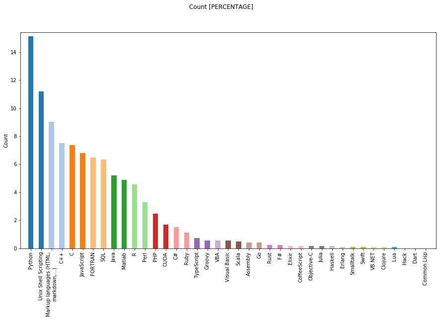

```python
_ = get_plot(perc_to_count, "multiple choices")
```

## Group of question: ukrse

### Are you a member of the UK RSE Association? (Members are people who have signed up to the UK RSE mailing list)

```python
v_to_count, filename  = get_count(df, ['ukrse1. Are you a member of the UK RSE Association? (Members are people who have signed up to the UK RSE mailing list at www.rse.ac.uk)'], "y/n/na", "./../survey_creation/uk_17/listAnswers/.csv", "False", "./uk_2017/output/")
```

```python
perc_to_count = get_percentage(v_to_count, filename)
```

```python
display_side_by_side(v_to_count,perc_to_count)
```

|  | Yes | No | nan |
| --- | --- | --- | --- |
| Are you a member of the UK RSE Association? (Members are people who have signed up to the UK RSE mailing list at www.rse.ac.uk) | 156 | 62 | 35 |

|  | Yes | No |
| --- | --- | --- |
| Are you a member of the UK RSE Association? (Members are people who have signed up to the UK RSE mailing list at www.rse.ac.uk) [PERCENTAGE] | 71.56 | 28.44 |

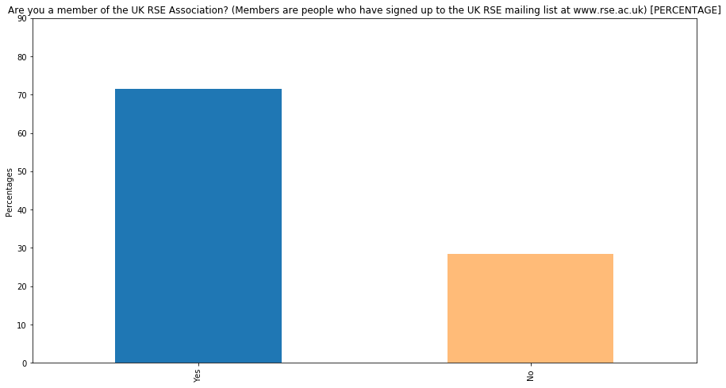

```python
_ = get_plot(perc_to_count, "y/n/na")
```

### How do you meet other RSEs?

```python
v_to_count, filename  = get_count(df, ['ukrse2[SQ001]. How do you meet other RSEs? [UK RSE Association]', 'ukrse2[SQ002]. How do you meet other RSEs? [Local RSE group/network]', 'ukrse2[SQ003]. How do you meet other RSEs? [N/A]'], "multiple choices", "./../survey_creation/uk_17/listAnswers/ukrse.csv", "False", "./uk_2017/output/")
```

```python
perc_to_count = get_percentage(v_to_count, filename)
```

```python
display_side_by_side(v_to_count,perc_to_count)
```

|  | Count |
| --- | --- |
| N/A | 101 |
| UK RSE Association | 72 |
| Local RSE group/network | 66 |

|  | Count [PERCENTAGE] |
| --- | --- |
| N/A | 42.26 |
| UK RSE Association | 30.13 |
| Local RSE group/network | 27.62 |

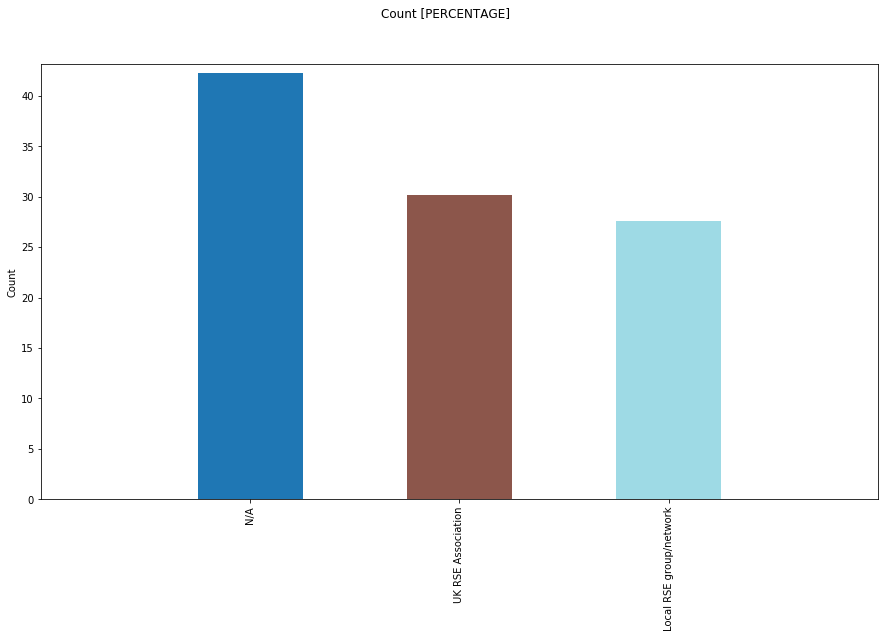

```python
_ = get_plot(perc_to_count, "multiple choices")
```

## Group of question: skill

### What three skills would you like to acquire or improve to help your work as a Research Software Engineer? The skills can be technical and non-technical.